# Assignment 2

# Data Exploration and Preprocessing

## Names:

### 1. Amr Mohamed Fathy (46)

### 2. Abdelrhman Yasser (37)

## Exploring Dataset

We will begin our lab by exploring machine-learning-database :

- Total number of Instances = 2310
  - Training data: 210 samples
  - Testing data: 2100 samples
- Classes are brickface, sky, foliage, cement, window, path, and grass. and distributed between the training data and testing data as following
  - 30 instances per class for training data.
  - 300 instances per class for test data.
- Now we will explore the attributes of the dataset:
  1. region-centroid-col: the column of the center pixel of the region.
  2. region-centroid-row: the row of the center pixel of the region.
  3. region-pixel-count: the number of pixels in a region = 9.
  4. short-line-density-5: the results of a line extractoin algorithm that counts how many lines of length 5 (any orientation) with low contrast, less than or equal to 5, go through the region.
  5. short-line-density-2: same as short-line-density-5 but counts lines of high contrast, greater than 5.
  6. vedge-mean: measure the contrast of horizontally adjacent pixels in the region. There are 6, the mean and standard deviation are given. This attribute is used as a vertical edge detector.
  7. vegde-sd: explained as part in point 6.
  8. hedge-mean: measures the contrast of vertically adjacent pixels. Used for horizontal line detection.
  9. hedge-sd: explained as part in point 8.
  10. intensity-mean: the average over the region of (R + G + B)/3
  11. rawred-mean: the average over the region of the R value.
  12. rawblue-mean: the average over the region of the B value.
  13. rawgreen-mean: the average over the region of the G value.
  14. exred-mean: measure the excess red: (2R - (G + B))
  15. exblue-mean: measure the excess blue: (2B - (G + R))
  16. exgreen-mean: measure the excess green: (2G - (R + B))
  17. value-mean: 3-d nonlinear transformation of RGB. (Algorithm can be found in Foley and VanDam, Fundamentals of Interactive Computer Graphics)
  18. saturatoin-mean: (see 17)
  19. hue-mean: (see 17)

## Imports

```python
import numpy as np
import pandas as pd
import matplotlib.pyplot as plt
import seaborn as sns
```

## Loading dataset

```python
def parse_data(url):
  df = pd.read_csv(url, skiprows=2, index_col=False)
  column_names = ['label'] + list(df.columns.astype('str'))
  df = pd.read_csv(url, skiprows=4, index_col=False, names=column_names)
  return df
```

```python
# Loading training dataset
training_df = parse_data(url='https://archive.ics.uci.edu/ml/machine-learning-databases/image/segmentation.data')
print("Training dataset contains {} samples".format(training_df.shape[0]))
training_df.head()
```

```
Training dataset contains 210 samples
```

|  | label | REGION-CENTROID-COL | REGION-CENTROID-ROW | REGION-PIXEL-COUNT | SHORT-LINE-DENSITY-5 | SHORT-LINE-DENSITY-2 | VEDGE-MEAN | VEDGE-SD | HEDGE-MEAN | HEDGE-SD | INTENSITY-MEAN | RAWRED-MEAN | RAWBLUE-MEAN | RAWGREEN-MEAN | EXRED-MEAN | EXBLUE-MEAN | EXGREEN-MEAN | VALUE-MEAN | SATURATION-MEAN | HUE-MEAN |
| --- | --- | --- | --- | --- | --- | --- | --- | --- | --- | --- | --- | --- | --- | --- | --- | --- | --- | --- | --- | --- |
| 0 | BRICKFACE | 140.0 | 125.0 | 9 | 0.0 | 0.0 | 0.277778 | 0.062963 | 0.666667 | 0.311111 | 6.185185 | 7.333334 | 7.666666 | 3.555556 | 3.444444 | 4.444445 | -7.888889 | 7.777778 | 0.545635 | -1.121818 |
| 1 | BRICKFACE | 188.0 | 133.0 | 9 | 0.0 | 0.0 | 0.333333 | 0.266667 | 0.500000 | 0.077778 | 6.666666 | 8.333334 | 7.777778 | 3.888889 | 5.000000 | 3.333333 | -8.333333 | 8.444445 | 0.538580 | -0.924817 |
| 2 | BRICKFACE | 105.0 | 139.0 | 9 | 0.0 | 0.0 | 0.277778 | 0.107407 | 0.833333 | 0.522222 | 6.111111 | 7.555555 | 7.222222 | 3.555556 | 4.333334 | 3.333333 | -7.666666 | 7.555555 | 0.532628 | -0.965946 |
| 3 | BRICKFACE | 34.0 | 137.0 | 9 | 0.0 | 0.0 | 0.500000 | 0.166667 | 1.111111 | 0.474074 | 5.851852 | 7.777778 | 6.444445 | 3.333333 | 5.777778 | 1.777778 | -7.555555 | 7.777778 | 0.573633 | -0.744272 |
| 4 | BRICKFACE | 39.0 | 111.0 | 9 | 0.0 | 0.0 | 0.722222 | 0.374074 | 0.888889 | 0.429629 | 6.037037 | 7.000000 | 7.666666 | 3.444444 | 2.888889 | 4.888889 | -7.777778 | 7.888889 | 0.562919 | -1.175773 |

```python
# Loading testing dataset
testing_df = parse_data(url='https://archive.ics.uci.edu/ml/machine-learning-databases/image/segmentation.test')
print("Testing dataset contains {} samples".format(testing_df.shape[0]))
testing_df.head()
```

```
Testing dataset contains 2100 samples
```

|  | label | REGION-CENTROID-COL | REGION-CENTROID-ROW | REGION-PIXEL-COUNT | SHORT-LINE-DENSITY-5 | SHORT-LINE-DENSITY-2 | VEDGE-MEAN | VEDGE-SD | HEDGE-MEAN | HEDGE-SD | INTENSITY-MEAN | RAWRED-MEAN | RAWBLUE-MEAN | RAWGREEN-MEAN | EXRED-MEAN | EXBLUE-MEAN | EXGREEN-MEAN | VALUE-MEAN | SATURATION-MEAN | HUE-MEAN |
| --- | --- | --- | --- | --- | --- | --- | --- | --- | --- | --- | --- | --- | --- | --- | --- | --- | --- | --- | --- | --- |
| 0 | GRASS | 110.0 | 189.0 | 9 | 0.0 | 0.0 | 1.000000 | 0.666667 | 1.222222 | 1.186342 | 12.925926 | 10.888889 | 9.222222 | 18.666668 | -6.111111 | -11.111111 | 17.222221 | 18.666668 | 0.508139 | 1.910864 |
| 1 | GRASS | 86.0 | 187.0 | 9 | 0.0 | 0.0 | 1.111111 | 0.720082 | 1.444444 | 0.750309 | 13.740741 | 11.666667 | 10.333334 | 19.222221 | -6.222222 | -10.222222 | 16.444445 | 19.222221 | 0.463329 | 1.941465 |
| 2 | GRASS | 225.0 | 244.0 | 9 | 0.0 | 0.0 | 3.388889 | 2.195113 | 3.000000 | 1.520234 | 12.259259 | 10.333334 | 9.333334 | 17.111110 | -5.777778 | -8.777778 | 14.555555 | 17.111110 | 0.480149 | 1.987902 |
| 3 | GRASS | 47.0 | 232.0 | 9 | 0.0 | 0.0 | 1.277778 | 1.254621 | 1.000000 | 0.894427 | 12.703704 | 11.000000 | 9.000000 | 18.111110 | -5.111111 | -11.111111 | 16.222221 | 18.111110 | 0.500966 | 1.875362 |
| 4 | GRASS | 97.0 | 186.0 | 9 | 0.0 | 0.0 | 1.166667 | 0.691215 | 1.166667 | 1.005540 | 15.592592 | 13.888889 | 11.777778 | 21.111110 | -5.111111 | -11.444445 | 16.555555 | 21.111110 | 0.442661 | 1.863654 |

```python
# Merge datasets
total_df = pd.concat([training_df, testing_df])
total_df.sort_values('label')
print("Total dataset contains {} samples".format(total_df.shape[0]))
total_df.head()
```

```
Total dataset contains 2310 samples
```

|  | label | REGION-CENTROID-COL | REGION-CENTROID-ROW | REGION-PIXEL-COUNT | SHORT-LINE-DENSITY-5 | SHORT-LINE-DENSITY-2 | VEDGE-MEAN | VEDGE-SD | HEDGE-MEAN | HEDGE-SD | INTENSITY-MEAN | RAWRED-MEAN | RAWBLUE-MEAN | RAWGREEN-MEAN | EXRED-MEAN | EXBLUE-MEAN | EXGREEN-MEAN | VALUE-MEAN | SATURATION-MEAN | HUE-MEAN |
| --- | --- | --- | --- | --- | --- | --- | --- | --- | --- | --- | --- | --- | --- | --- | --- | --- | --- | --- | --- | --- |
| 0 | BRICKFACE | 140.0 | 125.0 | 9 | 0.0 | 0.0 | 0.277778 | 0.062963 | 0.666667 | 0.311111 | 6.185185 | 7.333334 | 7.666666 | 3.555556 | 3.444444 | 4.444445 | -7.888889 | 7.777778 | 0.545635 | -1.121818 |
| 1 | BRICKFACE | 188.0 | 133.0 | 9 | 0.0 | 0.0 | 0.333333 | 0.266667 | 0.500000 | 0.077778 | 6.666666 | 8.333334 | 7.777778 | 3.888889 | 5.000000 | 3.333333 | -8.333333 | 8.444445 | 0.538580 | -0.924817 |
| 2 | BRICKFACE | 105.0 | 139.0 | 9 | 0.0 | 0.0 | 0.277778 | 0.107407 | 0.833333 | 0.522222 | 6.111111 | 7.555555 | 7.222222 | 3.555556 | 4.333334 | 3.333333 | -7.666666 | 7.555555 | 0.532628 | -0.965946 |
| 3 | BRICKFACE | 34.0 | 137.0 | 9 | 0.0 | 0.0 | 0.500000 | 0.166667 | 1.111111 | 0.474074 | 5.851852 | 7.777778 | 6.444445 | 3.333333 | 5.777778 | 1.777778 | -7.555555 | 7.777778 | 0.573633 | -0.744272 |
| 4 | BRICKFACE | 39.0 | 111.0 | 9 | 0.0 | 0.0 | 0.722222 | 0.374074 | 0.888889 | 0.429629 | 6.037037 | 7.000000 | 7.666666 | 3.444444 | 2.888889 | 4.888889 | -7.777778 | 7.888889 | 0.562919 | -1.175773 |

## Dataset Summary

```python
total_df.describe()
```

|  | REGION-CENTROID-COL | REGION-CENTROID-ROW | REGION-PIXEL-COUNT | SHORT-LINE-DENSITY-5 | SHORT-LINE-DENSITY-2 | VEDGE-MEAN | VEDGE-SD | HEDGE-MEAN | HEDGE-SD | INTENSITY-MEAN | RAWRED-MEAN | RAWBLUE-MEAN | RAWGREEN-MEAN | EXRED-MEAN | EXBLUE-MEAN | EXGREEN-MEAN | VALUE-MEAN | SATURATION-MEAN | HUE-MEAN |
| --- | --- | --- | --- | --- | --- | --- | --- | --- | --- | --- | --- | --- | --- | --- | --- | --- | --- | --- | --- |
| count | 2310.000000 | 2310.000000 | 2310.0 | 2310.000000 | 2310.000000 | 2310.000000 | 2310.000000 | 2310.000000 | 2.310000e+03 | 2310.000000 | 2310.000000 | 2310.000000 | 2310.000000 | 2310.000000 | 2310.000000 | 2310.000000 | 2310.000000 | 2310.000000 | 2310.000000 |
| mean | 124.913853 | 123.417316 | 9.0 | 0.014334 | 0.004714 | 1.893939 | 5.709320 | 2.424723 | 8.243692e+00 | 37.051595 | 32.821308 | 44.187879 | 34.145599 | -12.690861 | 21.408850 | -8.717989 | 45.137470 | 0.426893 | -1.362897 |
| std | 72.956532 | 57.483851 | 0.0 | 0.040154 | 0.024234 | 2.698908 | 44.846457 | 3.610084 | 5.881152e+01 | 38.176410 | 35.036774 | 43.527461 | 36.364773 | 11.583562 | 19.571819 | 11.551628 | 42.921764 | 0.228309 | 1.545335 |
| min | 1.000000 | 11.000000 | 9.0 | 0.000000 | 0.000000 | 0.000000 | 0.000000 | 0.000000 | -1.589457e-08 | 0.000000 | 0.000000 | 0.000000 | 0.000000 | -49.666668 | -12.444445 | -33.888890 | 0.000000 | 0.000000 | -3.044175 |
| 25% | 62.000000 | 81.000000 | 9.0 | 0.000000 | 0.000000 | 0.722222 | 0.355555 | 0.777780 | 4.216373e-01 | 7.296296 | 7.000000 | 9.555555 | 6.027778 | -18.555555 | 4.138889 | -16.777779 | 11.555555 | 0.284235 | -2.188057 |
| 50% | 121.000000 | 122.000000 | 9.0 | 0.000000 | 0.000000 | 1.222224 | 0.833333 | 1.444444 | 9.629633e-01 | 21.592592 | 19.555555 | 27.666667 | 20.333334 | -10.888889 | 19.666666 | -10.888889 | 28.666666 | 0.374803 | -2.051200 |
| 75% | 189.000000 | 172.000000 | 9.0 | 0.000000 | 0.000000 | 2.166667 | 1.806367 | 2.555556 | 2.183269e+00 | 53.212964 | 47.333332 | 64.888890 | 46.500001 | -4.222222 | 35.777780 | -3.222222 | 64.888890 | 0.540123 | -1.562308 |
| max | 254.000000 | 251.000000 | 9.0 | 0.333333 | 0.222222 | 29.222221 | 991.718400 | 44.722225 | 1.386329e+03 | 143.444440 | 137.111110 | 150.888890 | 142.555560 | 9.888889 | 82.000000 | 24.666666 | 150.888890 | 1.000000 | 2.912480 |

## Splitting Dataset into values and class labels

```python
X = total_df.iloc[:,1:]
Y = total_df['label']
classes = np.unique(Y)
print('classes : {}'.format(classes))
print(X.shape)
display(X)
display(Y)
```

```
classes : ['BRICKFACE' 'CEMENT' 'FOLIAGE' 'GRASS' 'PATH' 'SKY' 'WINDOW']
(2310, 19)
```

|  | REGION-CENTROID-COL | REGION-CENTROID-ROW | REGION-PIXEL-COUNT | SHORT-LINE-DENSITY-5 | SHORT-LINE-DENSITY-2 | VEDGE-MEAN | VEDGE-SD | HEDGE-MEAN | HEDGE-SD | INTENSITY-MEAN | RAWRED-MEAN | RAWBLUE-MEAN | RAWGREEN-MEAN | EXRED-MEAN | EXBLUE-MEAN | EXGREEN-MEAN | VALUE-MEAN | SATURATION-MEAN | HUE-MEAN |
| --- | --- | --- | --- | --- | --- | --- | --- | --- | --- | --- | --- | --- | --- | --- | --- | --- | --- | --- | --- |
| 0 | 140.0 | 125.0 | 9 | 0.000000 | 0.000000 | 0.277778 | 0.062963 | 0.666667 | 0.311111 | 6.185185 | 7.333334 | 7.666666 | 3.555556 | 3.444444 | 4.444445 | -7.888889 | 7.777778 | 0.545635 | -1.121818 |
| 1 | 188.0 | 133.0 | 9 | 0.000000 | 0.000000 | 0.333333 | 0.266667 | 0.500000 | 0.077778 | 6.666666 | 8.333334 | 7.777778 | 3.888889 | 5.000000 | 3.333333 | -8.333333 | 8.444445 | 0.538580 | -0.924817 |
| 2 | 105.0 | 139.0 | 9 | 0.000000 | 0.000000 | 0.277778 | 0.107407 | 0.833333 | 0.522222 | 6.111111 | 7.555555 | 7.222222 | 3.555556 | 4.333334 | 3.333333 | -7.666666 | 7.555555 | 0.532628 | -0.965946 |
| 3 | 34.0 | 137.0 | 9 | 0.000000 | 0.000000 | 0.500000 | 0.166667 | 1.111111 | 0.474074 | 5.851852 | 7.777778 | 6.444445 | 3.333333 | 5.777778 | 1.777778 | -7.555555 | 7.777778 | 0.573633 | -0.744272 |
| 4 | 39.0 | 111.0 | 9 | 0.000000 | 0.000000 | 0.722222 | 0.374074 | 0.888889 | 0.429629 | 6.037037 | 7.000000 | 7.666666 | 3.444444 | 2.888889 | 4.888889 | -7.777778 | 7.888889 | 0.562919 | -1.175773 |
| 5 | 16.0 | 128.0 | 9 | 0.000000 | 0.000000 | 0.500000 | 0.077778 | 0.666667 | 0.311111 | 5.555555 | 6.888889 | 6.666666 | 3.111111 | 4.000000 | 3.333333 | -7.333334 | 7.111111 | 0.561508 | -0.985811 |
| 6 | 26.0 | 67.0 | 9 | 0.111111 | 0.000000 | 1.000000 | 0.888890 | 2.444445 | 3.185185 | 20.000000 | 19.555555 | 25.888890 | 14.555555 | -1.333333 | 17.666666 | -16.333334 | 25.888890 | 0.436939 | -1.623202 |
| 7 | 14.0 | 110.0 | 9 | 0.000000 | 0.000000 | 1.722222 | 5.351850 | 2.666667 | 1.022223 | 17.925926 | 18.888890 | 21.444445 | 13.444445 | 2.888889 | 10.555555 | -13.444445 | 21.444445 | 0.368848 | -1.345096 |
| 8 | 11.0 | 108.0 | 9 | 0.000000 | 0.000000 | 1.333333 | 0.800000 | 1.388889 | 0.951852 | 17.666666 | 19.000000 | 21.111110 | 12.888889 | 4.000000 | 10.333333 | -14.333333 | 21.111110 | 0.388756 | -1.302133 |
| 9 | 85.0 | 101.0 | 9 | 0.000000 | 0.000000 | 1.333333 | 1.288888 | 1.277778 | 1.218518 | 21.296297 | 21.222221 | 26.777779 | 15.888889 | -0.222222 | 16.444445 | -16.222221 | 26.777779 | 0.404792 | -1.558599 |
| 10 | 18.0 | 145.0 | 9 | 0.000000 | 0.000000 | 0.388889 | 0.018518 | 0.611111 | 0.374074 | 3.925926 | 5.555555 | 4.000000 | 2.222222 | 4.888889 | 0.222222 | -5.111111 | 5.555555 | 0.600529 | -0.570940 |
| 11 | 23.0 | 55.0 | 9 | 0.000000 | 0.000000 | 2.222222 | 3.674073 | 1.777777 | 0.785185 | 23.444445 | 21.666666 | 31.111110 | 17.555555 | -5.333334 | 23.000000 | -17.666666 | 31.111110 | 0.435070 | -1.771163 |
| 12 | 196.0 | 129.0 | 9 | 0.000000 | 0.000000 | 0.833333 | 0.433333 | 0.666667 | 0.177778 | 6.333334 | 7.888889 | 7.333334 | 3.777778 | 4.666666 | 3.000000 | -7.666666 | 8.222222 | 0.540123 | -0.932783 |
| 13 | 80.0 | 116.0 | 9 | 0.000000 | 0.000000 | 1.500000 | 1.633333 | 1.555556 | 0.874074 | 21.703703 | 21.222221 | 27.555555 | 16.333334 | -1.444444 | 17.555555 | -16.111110 | 27.555555 | 0.407364 | -1.632243 |
| 14 | 2.0 | 44.0 | 9 | 0.000000 | 0.000000 | 2.166667 | 2.388888 | 2.388890 | 1.529629 | 18.740740 | 17.333334 | 25.222221 | 13.666667 | -4.222222 | 19.444445 | -15.222222 | 25.222221 | 0.457681 | -1.753726 |
| 15 | 120.0 | 136.0 | 9 | 0.000000 | 0.000000 | 0.611111 | 0.418519 | 1.000000 | 0.444444 | 6.259259 | 7.777778 | 7.222222 | 3.777778 | 4.555555 | 2.888889 | -7.444445 | 8.000000 | 0.529541 | -0.924607 |
| 16 | 146.0 | 124.0 | 9 | 0.000000 | 0.000000 | 0.500000 | 0.166667 | 0.388889 | 0.107407 | 6.037037 | 7.444445 | 7.333334 | 3.333333 | 4.222222 | 3.888889 | -8.111111 | 7.666666 | 0.563492 | -1.024730 |
| 17 | 23.0 | 85.0 | 9 | 0.000000 | 0.000000 | 1.444444 | 1.051852 | 1.777778 | 0.962963 | 17.962963 | 18.888890 | 21.888890 | 13.111111 | 2.777778 | 11.777778 | -14.555555 | 21.888890 | 0.399751 | -1.386867 |
| 18 | 138.0 | 116.0 | 9 | 0.000000 | 0.000000 | 0.611111 | 0.151852 | 0.444444 | 0.207407 | 6.481482 | 7.555555 | 8.222222 | 3.666667 | 3.222222 | 5.222222 | -8.444445 | 8.333334 | 0.559171 | -1.191070 |
| 19 | 229.0 | 124.0 | 9 | 0.000000 | 0.000000 | 0.888889 | 0.074074 | 0.888889 | 0.340741 | 5.888889 | 7.111111 | 7.111111 | 3.444444 | 3.666667 | 3.666667 | -7.333334 | 7.555555 | 0.545855 | -1.037663 |
| 20 | 22.0 | 116.0 | 9 | 0.000000 | 0.000000 | 0.388889 | 0.107407 | 0.333333 | 0.133333 | 5.629630 | 6.777778 | 7.000000 | 3.111111 | 3.444444 | 4.111111 | -7.555555 | 7.333334 | 0.575397 | -1.099624 |
| 21 | 121.0 | 60.0 | 9 | 0.000000 | 0.000000 | 2.277778 | 2.329629 | 2.888889 | 2.874074 | 26.740740 | 24.666666 | 35.222220 | 20.333334 | -6.222222 | 25.444445 | -19.222221 | 35.222220 | 0.422300 | -1.776113 |
| 22 | 33.0 | 149.0 | 9 | 0.000000 | 0.000000 | 0.555556 | 0.251852 | 0.722222 | 0.151852 | 5.444445 | 4.111111 | 8.666667 | 3.555556 | -4.000000 | 9.666667 | -5.666666 | 8.666667 | 0.578339 | -1.985703 |
| 23 | 80.0 | 95.0 | 9 | 0.000000 | 0.000000 | 1.222222 | 1.007408 | 0.944444 | 0.551851 | 21.407408 | 21.333334 | 26.666666 | 16.222223 | -0.222222 | 15.777778 | -15.555555 | 26.666666 | 0.390436 | -1.567327 |
| 24 | 96.0 | 84.0 | 9 | 0.000000 | 0.000000 | 1.500000 | 1.277777 | 1.611111 | 2.285188 | 23.851852 | 23.555555 | 30.000000 | 18.000000 | -0.888889 | 18.444445 | -17.555555 | 30.000000 | 0.398791 | -1.598867 |
| 25 | 145.0 | 102.0 | 9 | 0.000000 | 0.000000 | 0.888889 | 0.607408 | 2.611111 | 1.485186 | 23.074074 | 22.111110 | 29.777779 | 17.333334 | -2.888889 | 20.111110 | -17.222221 | 29.777779 | 0.417763 | -1.685440 |
| 26 | 18.0 | 138.0 | 9 | 0.000000 | 0.000000 | 0.888889 | 0.562963 | 0.833333 | 0.300000 | 5.740741 | 7.333334 | 6.555555 | 3.333333 | 4.777778 | 2.444444 | -7.222222 | 7.333334 | 0.543871 | -0.862108 |
| 27 | 138.0 | 133.0 | 9 | 0.000000 | 0.000000 | 0.666667 | 0.444444 | 1.166667 | 0.211111 | 6.444445 | 7.777778 | 7.888889 | 3.666667 | 4.000000 | 4.333334 | -8.333333 | 8.222222 | 0.558201 | -1.077659 |
| 28 | 121.0 | 113.0 | 9 | 0.000000 | 0.000000 | 1.722222 | 1.529630 | 2.944444 | 1.529629 | 20.259260 | 20.000000 | 25.444445 | 15.333333 | -0.777778 | 15.555555 | -14.777778 | 25.444445 | 0.396589 | -1.585609 |
| 29 | 95.0 | 57.0 | 9 | 0.000000 | 0.000000 | 1.833333 | 3.411111 | 2.111111 | 1.718517 | 26.296297 | 24.666666 | 34.444447 | 19.777779 | -4.888889 | 24.444445 | -19.555555 | 34.444447 | 0.425691 | -1.739017 |
| ... | ... | ... | ... | ... | ... | ... | ... | ... | ... | ... | ... | ... | ... | ... | ... | ... | ... | ... | ... |
| 2070 | 47.0 | 189.0 | 9 | 0.000000 | 0.000000 | 2.277777 | 4.551854 | 5.888889 | 14.607409 | 29.629630 | 26.777779 | 36.555557 | 25.555555 | -8.555555 | 20.777779 | -12.222222 | 36.555557 | 0.297413 | -1.954574 |
| 2071 | 142.0 | 182.0 | 9 | 0.000000 | 0.000000 | 2.499999 | 1.099999 | 2.277777 | 3.618518 | 34.518520 | 31.555555 | 42.222220 | 29.777779 | -8.888889 | 23.111110 | -14.222222 | 42.222220 | 0.293208 | -1.943038 |
| 2072 | 249.0 | 154.0 | 9 | 0.000000 | 0.111111 | 4.222222 | 18.162964 | 1.722222 | 3.174073 | 4.296296 | 2.555556 | 7.666666 | 2.666667 | -5.222222 | 10.111111 | -4.888889 | 7.666666 | 0.815344 | -2.095813 |
| 2073 | 152.0 | 152.0 | 9 | 0.000000 | 0.000000 | 0.166667 | 0.033333 | 2.111111 | 4.340741 | 1.407407 | 1.000000 | 2.444444 | 0.777778 | -1.222222 | 3.111111 | -1.888889 | 2.444444 | 0.439153 | -2.000272 |
| 2074 | 150.0 | 152.0 | 9 | 0.000000 | 0.000000 | 0.111111 | 0.029630 | 2.055556 | 3.574075 | 1.370370 | 1.000000 | 2.333333 | 0.777778 | -1.111111 | 2.888889 | -1.777778 | 2.333333 | 0.537037 | -2.007351 |
| 2075 | 121.0 | 154.0 | 9 | 0.000000 | 0.000000 | 0.444444 | 0.118519 | 2.611111 | 5.751853 | 1.851852 | 1.555556 | 3.000000 | 1.000000 | -0.888889 | 3.444444 | -2.555556 | 3.000000 | 0.534392 | -1.905926 |
| 2076 | 150.0 | 152.0 | 9 | 0.000000 | 0.000000 | 0.111111 | 0.029630 | 2.055556 | 3.574075 | 1.370370 | 1.000000 | 2.333333 | 0.777778 | -1.111111 | 2.888889 | -1.777778 | 2.333333 | 0.537037 | -2.007351 |
| 2077 | 211.0 | 154.0 | 9 | 0.000000 | 0.000000 | 0.111111 | 0.029630 | 0.388889 | 0.062963 | 0.259259 | 0.000000 | 0.777778 | 0.000000 | -0.777778 | 1.555556 | -0.777778 | 0.777778 | 0.555556 | -2.094395 |
| 2078 | 173.0 | 152.0 | 9 | 0.000000 | 0.000000 | 0.222222 | 0.029630 | 0.833333 | 0.166667 | 3.592593 | 2.666667 | 5.777778 | 2.333333 | -2.777778 | 6.555555 | -3.777778 | 5.777778 | 0.599735 | -1.997796 |
| 2079 | 25.0 | 155.0 | 9 | 0.000000 | 0.000000 | 5.722223 | 99.751870 | 18.000000 | 151.688870 | 14.333333 | 13.000000 | 18.666668 | 11.333333 | -4.000000 | 13.000000 | -9.000000 | 21.444445 | 0.646298 | -1.797435 |
| 2080 | 215.0 | 153.0 | 9 | 0.000000 | 0.111111 | 19.666666 | 8.044466 | 1.111111 | 3.896296 | 8.333333 | 5.333334 | 13.444445 | 6.222222 | -9.000000 | 15.333333 | -6.333334 | 13.444445 | 0.769577 | -2.143890 |
| 2081 | 221.0 | 154.0 | 9 | 0.111111 | 0.111111 | 4.222222 | 2.740737 | 1.277778 | 0.596296 | 6.481482 | 4.333334 | 10.777778 | 4.333334 | -6.444445 | 12.888889 | -6.444445 | 10.777778 | 0.624800 | -2.087985 |
| 2082 | 145.0 | 155.0 | 9 | 0.000000 | 0.111111 | 4.944444 | 35.618523 | 9.944445 | 121.396286 | 11.296296 | 7.777778 | 17.555555 | 8.555555 | -10.555555 | 18.777779 | -8.222222 | 17.555555 | 0.747294 | -2.140531 |
| 2083 | 66.0 | 155.0 | 9 | 0.000000 | 0.000000 | 3.722222 | 21.796297 | 7.722223 | 71.574066 | 8.259259 | 5.888889 | 12.666667 | 6.222222 | -7.111111 | 13.222222 | -6.111111 | 12.666667 | 0.300624 | -2.147622 |
| 2084 | 46.0 | 154.0 | 9 | 0.111111 | 0.000000 | 3.166667 | 8.211110 | 1.611111 | 1.218518 | 6.370370 | 9.666667 | 4.666667 | 4.777778 | 9.888889 | -5.111111 | -4.777778 | 9.666667 | 0.561927 | -0.004927 |
| 2085 | 86.0 | 155.0 | 9 | 0.000000 | 0.000000 | 4.277778 | 10.551853 | 5.388889 | 60.240738 | 8.740741 | 6.666666 | 12.888889 | 6.666666 | -6.222222 | 12.444445 | -6.222222 | 12.888889 | 0.392385 | -2.079296 |
| 2086 | 248.0 | 153.0 | 9 | 0.000000 | 0.000000 | 0.277778 | 0.062963 | 0.111111 | 0.029630 | 0.370370 | 0.000000 | 1.111111 | 0.000000 | -1.111111 | 2.222222 | -1.111111 | 1.111111 | 0.888889 | -2.094395 |
| 2087 | 208.0 | 154.0 | 9 | 0.000000 | 0.111111 | 11.666667 | 125.866700 | 0.944444 | 0.685184 | 8.703704 | 5.888889 | 13.888889 | 6.333334 | -8.444445 | 15.555555 | -7.111111 | 13.888889 | 0.771517 | -2.066916 |
| 2088 | 43.0 | 152.0 | 9 | 0.000000 | 0.000000 | 1.944444 | 1.707408 | 1.222222 | 0.829630 | 1.518519 | 1.000000 | 2.888889 | 0.666667 | -1.555556 | 4.111111 | -2.555556 | 2.888889 | 0.648677 | -1.933239 |
| 2089 | 6.0 | 154.0 | 9 | 0.000000 | 0.000000 | 0.111111 | 0.029630 | 0.111111 | 0.029630 | 0.074074 | 0.000000 | 0.222222 | 0.000000 | -0.222222 | 0.444444 | -0.222222 | 0.222222 | 0.222222 | -2.094395 |
| 2090 | 152.0 | 155.0 | 9 | 0.000000 | 0.000000 | 0.500000 | 0.611111 | 10.777778 | 131.807390 | 7.296296 | 5.333334 | 11.000000 | 5.555555 | -5.888889 | 11.111111 | -5.222222 | 11.000000 | 0.500000 | -2.115567 |
| 2091 | 79.0 | 154.0 | 9 | 0.000000 | 0.000000 | 1.111111 | 1.585185 | 0.166667 | 0.077778 | 0.740741 | 0.444444 | 1.555556 | 0.222222 | -0.888889 | 2.444444 | -1.555556 | 1.555556 | 0.288889 | -1.919639 |
| 2092 | 166.0 | 154.0 | 9 | 0.000000 | 0.000000 | 0.111111 | 0.029630 | 0.444444 | 0.074074 | 0.703704 | 0.222222 | 1.888889 | 0.000000 | -1.444444 | 3.555556 | -2.111111 | 1.888889 | 1.000000 | -2.017510 |
| 2093 | 173.0 | 158.0 | 9 | 0.111111 | 0.000000 | 1.888889 | 3.674074 | 1.166667 | 0.477778 | 8.370370 | 7.111111 | 11.777778 | 6.222222 | -3.777778 | 10.222222 | -6.444445 | 11.777778 | 0.472975 | -1.904651 |
| 2094 | 233.0 | 159.0 | 9 | 0.000000 | 0.000000 | 2.500000 | 0.522222 | 1.277778 | 1.574074 | 6.629630 | 5.111111 | 10.111111 | 4.666667 | -4.555555 | 10.444445 | -5.888889 | 10.111111 | 0.541667 | -1.999443 |
| 2095 | 32.0 | 158.0 | 9 | 0.000000 | 0.000000 | 0.944445 | 0.862963 | 0.833333 | 0.611111 | 7.962963 | 6.333334 | 11.888889 | 5.666666 | -4.888889 | 11.777778 | -6.888889 | 11.888889 | 0.520578 | -1.982834 |
| 2096 | 8.0 | 162.0 | 9 | 0.111111 | 0.000000 | 1.611111 | 2.062962 | 0.333333 | 0.133333 | 8.370370 | 6.666666 | 12.000000 | 6.444445 | -5.111111 | 10.888889 | -5.777778 | 12.000000 | 0.484805 | -2.044946 |
| 2097 | 128.0 | 161.0 | 9 | 0.000000 | 0.000000 | 0.555555 | 0.251852 | 0.777778 | 0.162963 | 7.148148 | 5.555555 | 10.888889 | 5.000000 | -4.777778 | 11.222222 | -6.444445 | 10.888889 | 0.540918 | -1.996307 |
| 2098 | 150.0 | 158.0 | 9 | 0.000000 | 0.000000 | 2.166667 | 1.633334 | 1.388889 | 0.418518 | 8.444445 | 7.000000 | 12.222222 | 6.111111 | -4.333334 | 11.333333 | -7.000000 | 12.222222 | 0.503086 | -1.943449 |
| 2099 | 124.0 | 162.0 | 9 | 0.111111 | 0.000000 | 1.388889 | 1.129630 | 2.000000 | 0.888889 | 10.037037 | 8.000000 | 14.555555 | 7.555555 | -6.111111 | 13.555555 | -7.444445 | 14.555555 | 0.479931 | -2.029312 |

2310 rows × 19 columns

```
0       BRICKFACE
1       BRICKFACE
2       BRICKFACE
3       BRICKFACE
4       BRICKFACE
5       BRICKFACE
6       BRICKFACE
7       BRICKFACE
8       BRICKFACE
9       BRICKFACE
10      BRICKFACE
11      BRICKFACE
12      BRICKFACE
13      BRICKFACE
14      BRICKFACE
```

[output cut: 47 more lines]

## Plotting the dataset

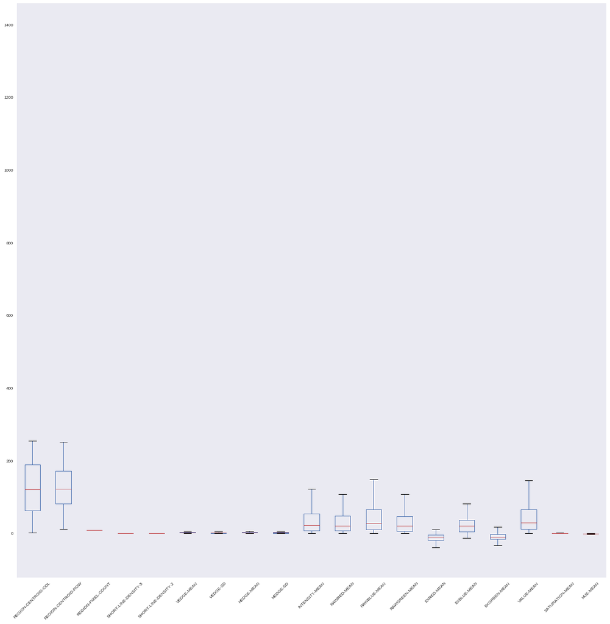

```python
total_df.iloc[:,1:].boxplot(grid=False, fontsize=8, rot=45, figsize=(20,20))
```

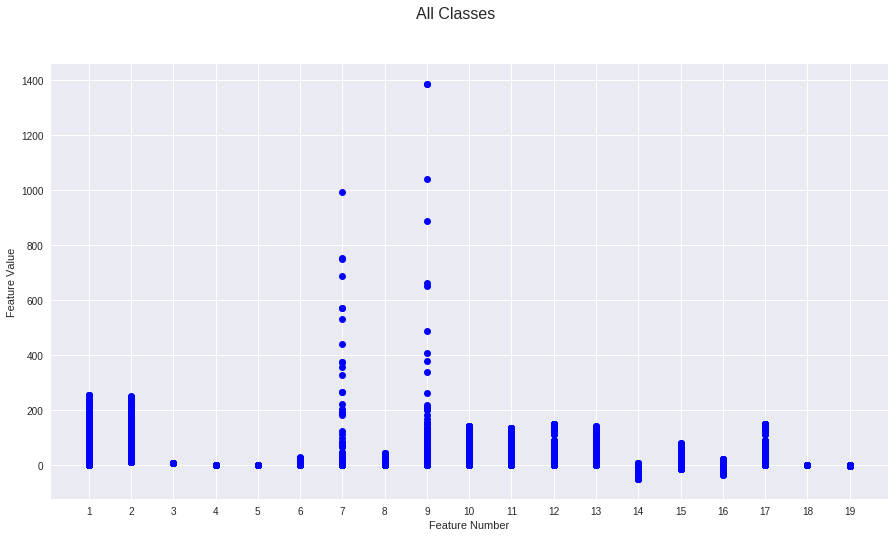

```python
def plot_data(x_data, y_data, x_title, y_title, title, xticks):
  fig = plt.figure(figsize=(15,8))
  plt.plot(x_data, y_data, 'bo')
  fig.suptitle(title, fontsize=16)
  plt.xlabel(x_title)
  plt.ylabel(y_title)
  plt.xticks(xticks)
  plt.show()
  return

classes_values = classes
feature_names = list(total_df.columns)
all_x = []
all_y = []
# plotting each class alone
for class_val in classes_values:
  # making feature points
  x = []
  y = []
  for i in range(1, len(feature_names)):
    feature_values = list(total_df[total_df['label'] == class_val].iloc[:, i])
    y = y + feature_values
    x = x + [i] * len(feature_values)
  all_x = all_x + x
  all_y = all_y + y
# plotting all classes together
plot_data(all_x, all_y, 'Feature Number', 'Feature Value', 'All Classes', [i for i in range(1, len(feature_names))])
```

## Pearson Correlation

Now we will calculate Pearson correlation

\begin{equation} Mean =\frac{1}{N} \sum X[i] \end{equation}

\begin{equation} Variance = \frac{1}{N} \sum_{1}^{N} X[i]^{2} - \overline{X}^{2} \end{equation}

\begin{equation} Covariance = E(A.B) - \overline{A} . \overline{B} \end{equation}

\begin{equation} r(A,B) = \frac{Cov(A,B)}{\sigma A \ \sigma B} \end{equation}

```python
pearson_coeff_matrix = X.corr(method='pearson')
display(pearson_coeff_matrix)
```

|  | REGION-CENTROID-COL | REGION-CENTROID-ROW | REGION-PIXEL-COUNT | SHORT-LINE-DENSITY-5 | SHORT-LINE-DENSITY-2 | VEDGE-MEAN | VEDGE-SD | HEDGE-MEAN | HEDGE-SD | INTENSITY-MEAN | RAWRED-MEAN | RAWBLUE-MEAN | RAWGREEN-MEAN | EXRED-MEAN | EXBLUE-MEAN | EXGREEN-MEAN | VALUE-MEAN | SATURATION-MEAN | HUE-MEAN |
| --- | --- | --- | --- | --- | --- | --- | --- | --- | --- | --- | --- | --- | --- | --- | --- | --- | --- | --- | --- |
| REGION-CENTROID-COL | 1.000000 | 0.026768 | NaN | -0.051962 | -0.015964 | -0.011304 | 0.021960 | -0.018914 | -0.001939 | 0.058957 | 0.054673 | 0.058169 | 0.063381 | -0.086816 | 0.043098 | 0.014035 | 0.060189 | -0.108214 | 0.039299 |
| REGION-CENTROID-ROW | 0.026768 | 1.000000 | NaN | 0.064891 | 0.041869 | 0.026146 | -0.053578 | 0.105223 | -0.021077 | -0.465240 | -0.468009 | -0.481521 | -0.437971 | 0.353175 | -0.490219 | 0.476421 | -0.458388 | 0.081556 | 0.592930 |
| REGION-PIXEL-COUNT | NaN | NaN | NaN | NaN | NaN | NaN | NaN | NaN | NaN | NaN | NaN | NaN | NaN | NaN | NaN | NaN | NaN | NaN | NaN |
| SHORT-LINE-DENSITY-5 | -0.051962 | 0.064891 | NaN | 1.000000 | -0.009024 | -0.020206 | -0.032781 | -0.021286 | -0.037996 | -0.018211 | -0.016755 | -0.021392 | -0.015604 | 0.028013 | -0.036164 | 0.033182 | -0.015886 | -0.043221 | 0.112989 |
| SHORT-LINE-DENSITY-2 | -0.015964 | 0.041869 | NaN | -0.009024 | 1.000000 | 0.262575 | 0.193728 | 0.303182 | 0.243155 | -0.006911 | -0.012471 | 0.003078 | -0.013435 | -0.044829 | 0.060979 | -0.058362 | -0.000145 | 0.016208 | -0.082939 |
| VEDGE-MEAN | -0.011304 | 0.026146 | NaN | -0.020206 | 0.262575 | 1.000000 | 0.637452 | 0.559491 | 0.488347 | 0.005129 | -0.005482 | 0.020498 | -0.003099 | -0.100457 | 0.106744 | -0.080120 | 0.018148 | -0.064827 | -0.097959 |
| VEDGE-SD | 0.021960 | -0.053578 | NaN | -0.032781 | 0.193728 | 0.637452 | 1.000000 | 0.471016 | 0.703049 | 0.003006 | -0.002138 | 0.006782 | 0.003410 | -0.049123 | 0.027659 | 0.002396 | 0.004804 | 0.002306 | -0.061591 |
| HEDGE-MEAN | -0.018914 | 0.105223 | NaN | -0.021286 | 0.303182 | 0.559491 | 0.471016 | 1.000000 | 0.668179 | 0.033973 | 0.026059 | 0.043846 | 0.029406 | -0.099434 | 0.093738 | -0.059111 | 0.042232 | -0.125955 | -0.093803 |
| HEDGE-SD | -0.001939 | -0.021077 | NaN | -0.037996 | 0.243155 | 0.488347 | 0.703049 | 0.668179 | 1.000000 | 0.013518 | 0.008538 | 0.016899 | 0.014121 | -0.056186 | 0.033647 | -0.000666 | 0.014858 | -0.024149 | -0.069988 |
| INTENSITY-MEAN | 0.058957 | -0.465240 | NaN | -0.018211 | -0.006911 | 0.005129 | 0.003006 | 0.033973 | 0.013518 | 1.000000 | 0.998112 | 0.995809 | 0.995842 | -0.830261 | 0.792257 | -0.509756 | 0.997385 | -0.608290 | -0.329845 |
| RAWRED-MEAN | 0.054673 | -0.468009 | NaN | -0.016755 | -0.012471 | -0.005482 | -0.002138 | 0.026059 | 0.008538 | 0.998112 | 1.000000 | 0.990813 | 0.994056 | -0.794457 | 0.769970 | -0.507899 | 0.992062 | -0.616928 | -0.328574 |
| RAWBLUE-MEAN | 0.058169 | -0.481521 | NaN | -0.021392 | 0.003078 | 0.020498 | 0.006782 | 0.043846 | 0.016899 | 0.995809 | 0.990813 | 1.000000 | 0.984659 | -0.855058 | 0.844741 | -0.573816 | 0.998644 | -0.595166 | -0.384925 |
| RAWGREEN-MEAN | 0.063381 | -0.437971 | NaN | -0.015604 | -0.013435 | -0.003099 | 0.003410 | 0.029406 | 0.014121 | 0.995842 | 0.994056 | 0.984659 | 1.000000 | -0.825950 | 0.742197 | -0.429265 | 0.990042 | -0.608988 | -0.261516 |
| EXRED-MEAN | -0.086816 | 0.353175 | NaN | 0.028013 | -0.044829 | -0.100457 | -0.049123 | -0.099434 | -0.056186 | -0.830261 | -0.794457 | -0.855058 | -0.825950 | 1.000000 | -0.846439 | 0.431350 | -0.859302 | 0.416229 | 0.279745 |
| EXBLUE-MEAN | 0.043098 | -0.490219 | NaN | -0.036164 | 0.060979 | 0.106744 | 0.027659 | 0.093738 | 0.033647 | 0.792257 | 0.769970 | 0.844741 | 0.742197 | -0.846439 | 1.000000 | -0.845512 | 0.826474 | -0.411371 | -0.638034 |
| EXGREEN-MEAN | 0.014035 | 0.476421 | NaN | 0.033182 | -0.058362 | -0.080120 | 0.002396 | -0.059111 | -0.000666 | -0.509756 | -0.507899 | -0.573816 | -0.429265 | 0.431350 | -0.845512 | 1.000000 | -0.538610 | 0.279602 | 0.800497 |
| VALUE-MEAN | 0.060189 | -0.458388 | NaN | -0.015886 | -0.000145 | 0.018148 | 0.004804 | 0.042232 | 0.014858 | 0.997385 | 0.992062 | 0.998644 | 0.990042 | -0.859302 | 0.826474 | -0.538610 | 1.000000 | -0.603522 | -0.341337 |
| SATURATION-MEAN | -0.108214 | 0.081556 | NaN | -0.043221 | 0.016208 | -0.064827 | 0.002306 | -0.125955 | -0.024149 | -0.608290 | -0.616928 | -0.595166 | -0.608988 | 0.416229 | -0.411371 | 0.279602 | -0.603522 | 1.000000 | -0.057479 |
| HUE-MEAN | 0.039299 | 0.592930 | NaN | 0.112989 | -0.082939 | -0.097959 | -0.061591 | -0.093803 | -0.069988 | -0.329845 | -0.328574 | -0.384925 | -0.261516 | 0.279745 | -0.638034 | 0.800497 | -0.341337 | -0.057479 | 1.000000 |

**Notice that pearson coeff between REGION-PIXEL-COUNT feature with all the others features is NaN as all REGION-PIXEL-COUNT values are the same which is equal to 9 . So the variance of REGION-PIXEL-COUNT feature is 0. So when we calculate the pearson using the following formula :** \begin{equation} r(A,B) = \frac{Cov(A,B)}{\sigma A \ \sigma B} \end{equation}

**we will get \begin{equation} r(A,B) = \frac{Cov(A,B)}{zero} \end{equation} which will result NaN value**

```python
def visualize_coeff_matrix(mat, norm=False):
  fig = plt.figure(figsize = (12,12))
  if norm==False:
    plt.imshow(mat, cmap='Reds')
  else:
    plt.imshow(mat, cmap='Reds', vmin=0, vmax=1)
  plt.colorbar()
  plt.xticks([i for i in range(0,mat.shape[0])])
  plt.yticks([i for i in range(0,mat.shape[0])])
```

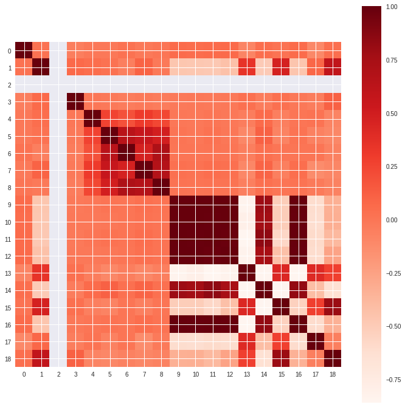

```python
visualize_coeff_matrix(pearson_coeff_matrix)
```

## Convariance Calculating

Now we will compute covariance matrix

```python
covariance_coeff_matrix = total_df.cov()
display(covariance_coeff_matrix)
```

|  | REGION-CENTROID-COL | REGION-CENTROID-ROW | REGION-PIXEL-COUNT | SHORT-LINE-DENSITY-5 | SHORT-LINE-DENSITY-2 | VEDGE-MEAN | VEDGE-SD | HEDGE-MEAN | HEDGE-SD | INTENSITY-MEAN | RAWRED-MEAN | RAWBLUE-MEAN | RAWGREEN-MEAN | EXRED-MEAN | EXBLUE-MEAN | EXGREEN-MEAN | VALUE-MEAN | SATURATION-MEAN | HUE-MEAN |
| --- | --- | --- | --- | --- | --- | --- | --- | --- | --- | --- | --- | --- | --- | --- | --- | --- | --- | --- | --- |
| REGION-CENTROID-COL | 5322.655633 | 112.261605 | 0.0 | -0.152222 | -0.028226 | -2.225830 | 71.850789 | -4.981611 | -8.318737 | 164.209187 | 139.753091 | 184.722513 | 168.151958 | -73.368285 | 61.539978 | 11.828309 | 188.478189 | -1.802488 | 4.430609 |
| REGION-CENTROID-ROW | 112.261605 | 3304.393117 | 0.0 | 0.149783 | 0.058327 | 4.056431 | -138.121244 | 21.835935 | -71.256512 | -1020.982645 | -942.593272 | -1204.825006 | -915.529680 | 235.168129 | -551.527028 | 316.358899 | -1130.983933 | 1.070354 | 52.671047 |
| REGION-PIXEL-COUNT | 0.000000 | 0.000000 | 0.0 | 0.000000 | 0.000000 | 0.000000 | 0.000000 | 0.000000 | 0.000000 | 0.000000 | 0.000000 | 0.000000 | 0.000000 | 0.000000 | 0.000000 | 0.000000 | 0.000000 | 0.000000 | 0.000000 |
| SHORT-LINE-DENSITY-5 | -0.152222 | 0.149783 | 0.0 | 0.001612 | -0.000009 | -0.002190 | -0.059032 | -0.003086 | -0.089729 | -0.027916 | -0.023573 | -0.037389 | -0.022785 | 0.013029 | -0.028421 | 0.015391 | -0.027379 | -0.000396 | 0.007011 |
| SHORT-LINE-DENSITY-2 | -0.028226 | 0.058327 | 0.0 | -0.000009 | 0.000587 | 0.017174 | 0.210548 | 0.026525 | 0.346558 | -0.006394 | -0.010589 | 0.003247 | -0.011840 | -0.012584 | 0.028923 | -0.016338 | -0.000151 | 0.000090 | -0.003106 |
| VEDGE-MEAN | -2.225830 | 4.056431 | 0.0 | -0.002190 | 0.017174 | 7.284104 | 77.154914 | 5.451284 | 77.513850 | 0.528485 | -0.518380 | 2.407979 | -0.304143 | -3.140597 | 5.638482 | -2.497886 | 2.102268 | -0.039945 | -0.408560 |
| VEDGE-SD | 71.850789 | -138.121244 | 0.0 | -0.059032 | 0.210548 | 77.154914 | 2011.204665 | 76.257247 | 1854.284580 | 5.147211 | -3.359009 | 13.239618 | 5.561028 | -25.518664 | 24.277221 | 1.241442 | 9.247399 | 0.023612 | -4.268463 |
| HEDGE-MEAN | -4.981611 | 21.835935 | 0.0 | -0.003086 | 0.026525 | 5.451284 | 76.257247 | 13.032705 | 141.864126 | 4.682097 | 3.296073 | 6.889813 | 3.860406 | -4.158073 | 6.623148 | -2.465074 | 6.543955 | -0.103814 | -0.523308 |
| HEDGE-SD | -8.318737 | -71.256512 | 0.0 | -0.089729 | 0.346558 | 77.513850 | 1854.284580 | 141.864126 | 3458.794558 | 30.350893 | 17.592150 | 43.260490 | 30.200059 | -38.276254 | 38.728788 | -0.452533 | 37.505597 | -0.324256 | -6.360770 |
| INTENSITY-MEAN | 164.209187 | -1020.982645 | 0.0 | -0.027916 | -0.006394 | 0.528485 | 5.147211 | 4.682097 | 30.350893 | 1457.438265 | 1335.052524 | 1654.758170 | 1382.504132 | -367.157227 | 591.959640 | -224.802412 | 1634.314320 | -5.301873 | -19.459342 |
| RAWRED-MEAN | 139.753091 | -942.593272 | 0.0 | -0.023573 | -0.010589 | -0.518380 | -3.359009 | 3.296073 | 17.592150 | 1335.052524 | 1227.575551 | 1511.050490 | 1266.531564 | -322.430926 | 527.993824 | -205.562896 | 1491.903072 | -4.934948 | -17.790149 |
| RAWBLUE-MEAN | 184.722513 | -1204.825006 | 0.0 | -0.037389 | 0.003247 | 2.407979 | 13.239618 | 6.889813 | 43.260490 | 1654.758170 | 1511.050490 | 1894.639872 | 1558.584186 | -431.123047 | 719.645018 | -288.521969 | 1865.742717 | -5.914601 | -25.891794 |
| RAWGREEN-MEAN | 168.151958 | -915.529680 | 0.0 | -0.022785 | -0.011840 | -0.304143 | 5.561028 | 3.860406 | 30.200059 | 1382.504132 | 1266.531564 | 1558.584186 | 1322.396679 | -347.917712 | 528.240086 | -180.322372 | 1545.297205 | -5.056070 | -14.696082 |
| EXRED-MEAN | -73.368285 | 235.168129 | 0.0 | 0.013029 | -0.012584 | -3.140597 | -25.518664 | -4.158073 | -38.276254 | -367.157227 | -322.430926 | -431.123047 | -347.917712 | 134.178899 | -191.897444 | 57.718544 | -427.233747 | 1.100776 | 5.007579 |
| EXBLUE-MEAN | 61.539978 | -551.527028 | 0.0 | -0.028421 | 0.028923 | 5.638482 | 24.277221 | 6.623148 | 38.728788 | 591.959640 | 527.993824 | 719.645018 | 528.240086 | -191.897444 | 383.056109 | -191.158664 | 694.285108 | -1.838183 | -19.297357 |
| EXGREEN-MEAN | 11.828309 | 316.358899 | 0.0 | 0.015391 | -0.016338 | -2.497886 | 1.241442 | -2.465074 | -0.452533 | -224.802412 | -205.562896 | -288.521969 | -180.322372 | 57.718544 | -191.158664 | 133.440119 | -267.051359 | 0.737408 | 14.289778 |
| VALUE-MEAN | 188.478189 | -1130.983933 | 0.0 | -0.027379 | -0.000151 | 2.102268 | 9.247399 | 6.543955 | 37.505597 | 1634.314320 | 1491.903072 | 1865.742717 | 1545.297205 | -427.233747 | 694.285108 | -267.051359 | 1842.277792 | -5.914180 | -22.640410 |
| SATURATION-MEAN | -1.802488 | 1.070354 | 0.0 | -0.000396 | 0.000090 | -0.039945 | 0.023612 | -0.103814 | -0.324256 | -5.301873 | -4.934948 | -5.914601 | -5.056070 | 1.100776 | -1.838183 | 0.737408 | -5.914180 | 0.052125 | -0.020279 |
| HUE-MEAN | 4.430609 | 52.671047 | 0.0 | 0.007011 | -0.003106 | -0.408560 | -4.268463 | -0.523308 | -6.360770 | -19.459342 | -17.790149 | -25.891794 | -14.696082 | 5.007579 | -19.297357 | 14.289778 | -22.640410 | -0.020279 | 2.388062 |

```
Before Scaling Covariance Matrix
```

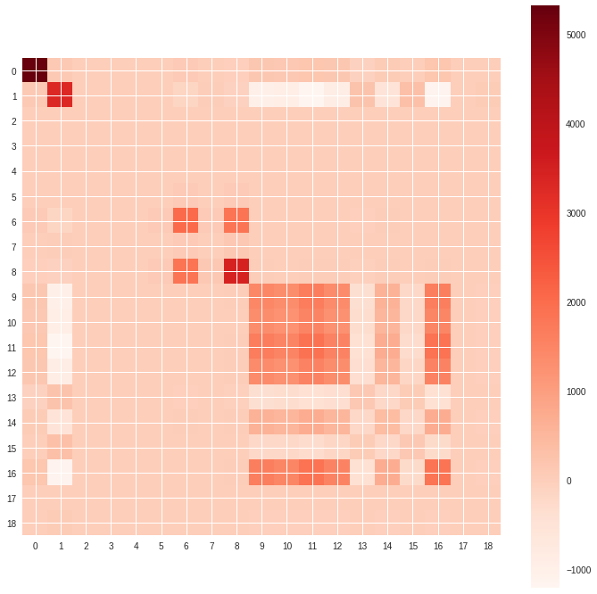

```python
print('Before Scaling Covariance Matrix')
visualize_coeff_matrix(covariance_coeff_matrix)
```

```
After Scaling Covariance Matrix
```

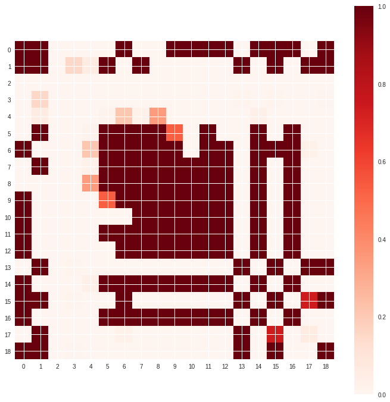

```python
print('After Scaling Covariance Matrix')
visualize_coeff_matrix(covariance_coeff_matrix, norm=True)
```

The relation between the covariance matrix of the dataset and the Pearson’s correlation matrix can be described as following: \begin{equation} r(A,B) = \frac{Cov(A,B)}{\sigma A \ \sigma B} \end{equation}

## Plotting Histograms

Plot the data histogram for each class separately . Let each class have only one plot with a different color for each attribute.

```python
def plot_histogram(bins, rwidth):
  colors = ['red', 'green', 'blue', 'olive', 'yellow', 'gray', 'black', 'gold', 'skyblue',
            'teal', 'cyan', 'tomato', 'pink', 'violet', 'plum', 'navy', 'c', 'm', 'y' ]
  for class_val in classes:
    data = total_df[total_df['label'] == class_val].iloc[:,1:]
    plt.figure(figsize=(20,10))
    plt.title("class " + class_val )
    plt.xlabel("Feature Value")
    plt.ylabel("Value Frequency")
    plt.hist(np.array(data), bins=bins, color=np.array(colors), label=classes_names, rwidth=rwidth)
    plt.legend()
    plt.show()
```

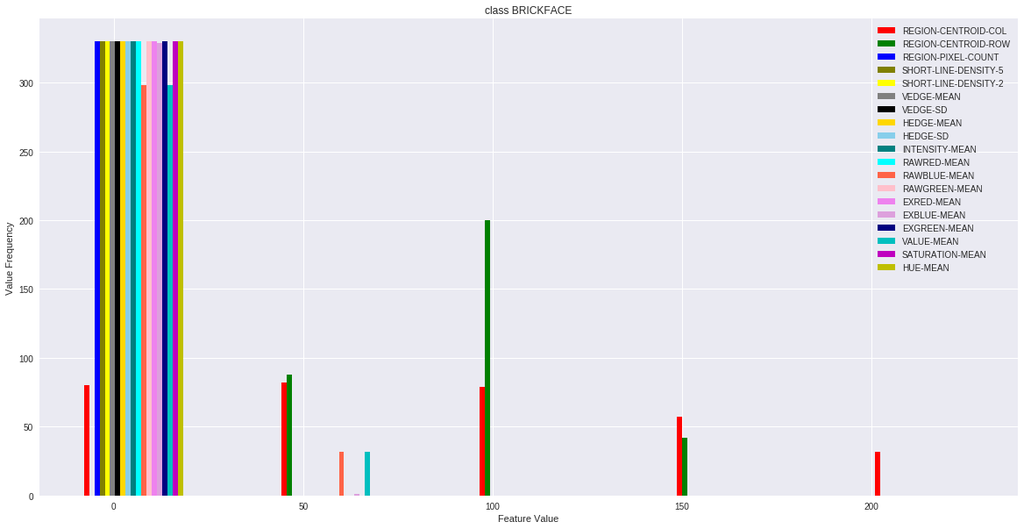

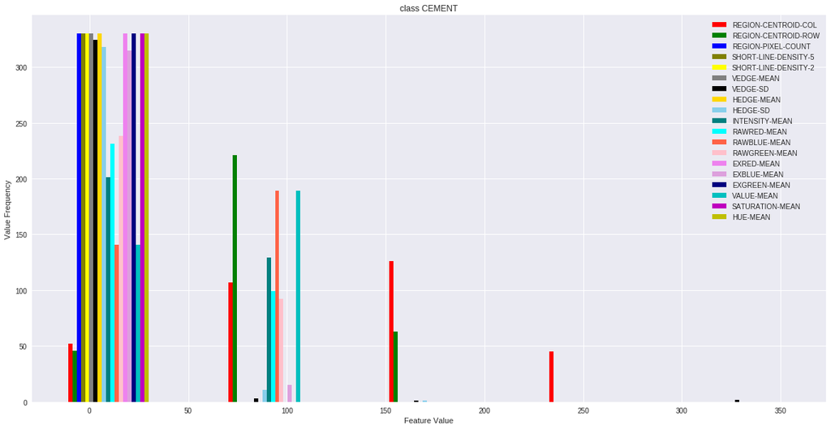

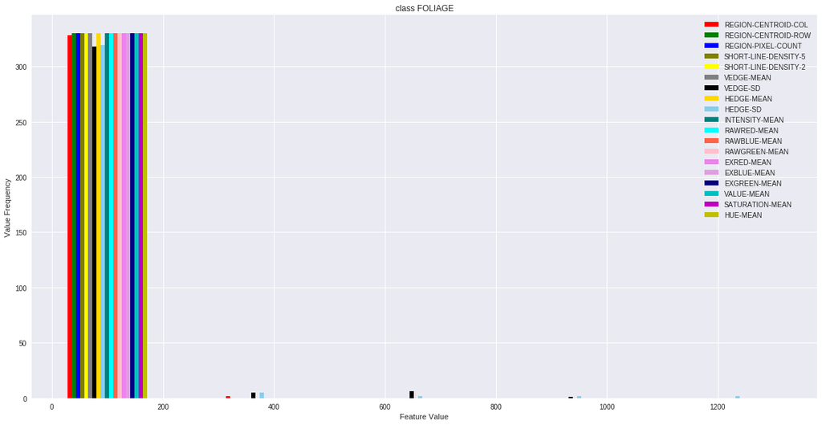

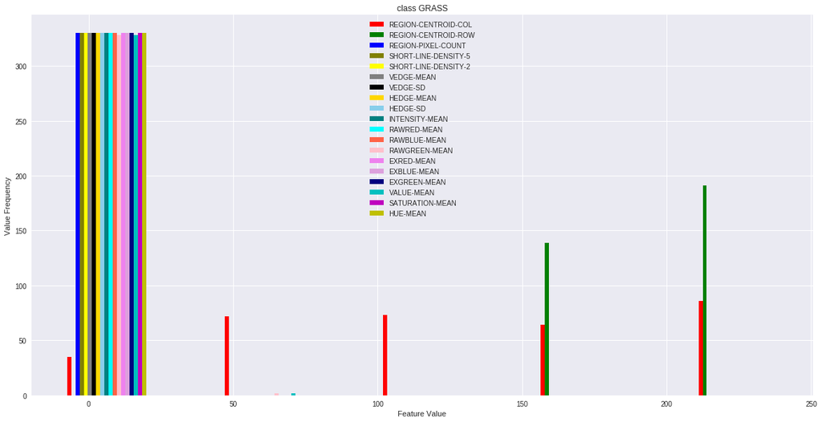

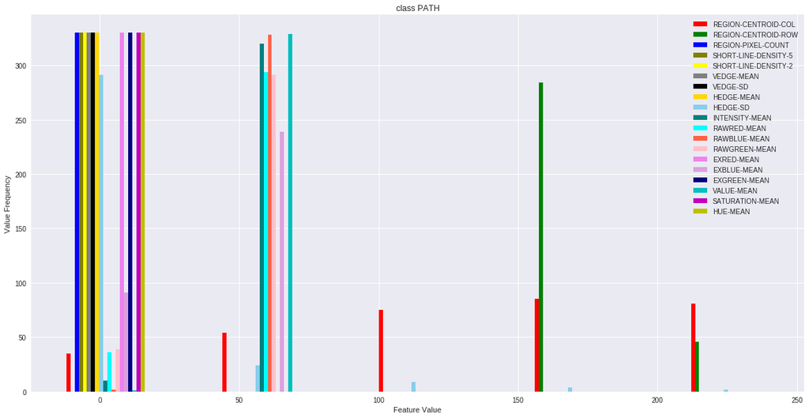

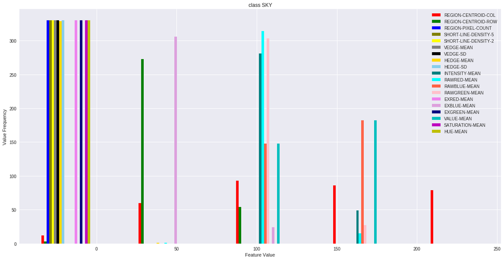

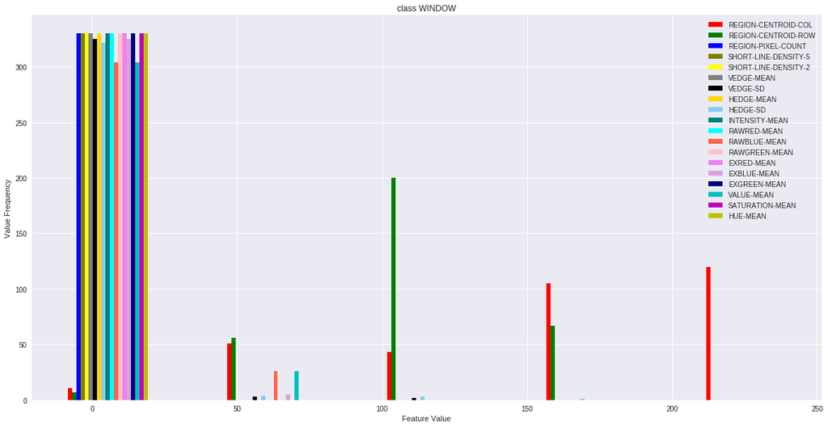

```python
# 5 bins
plot_histogram(5, 0.5)
```

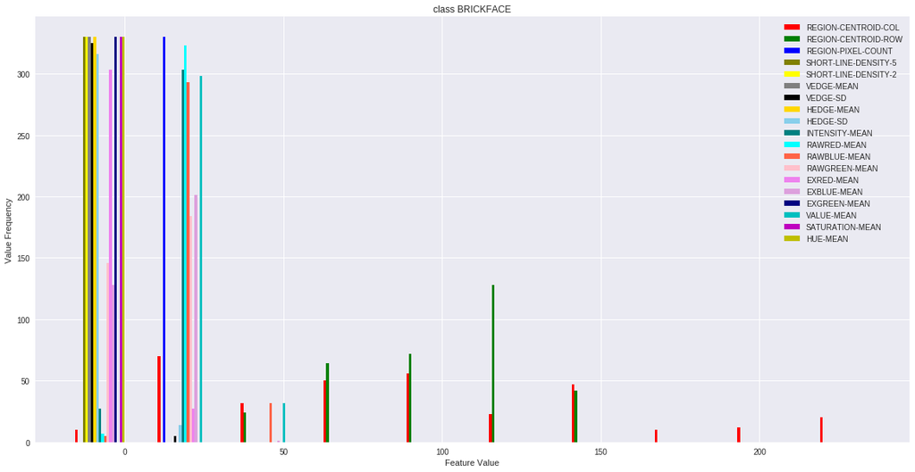

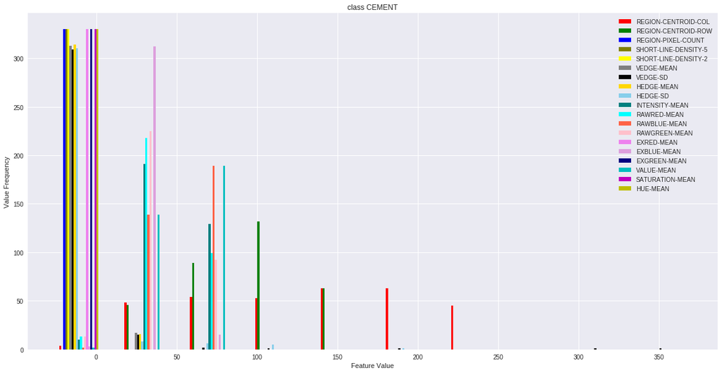

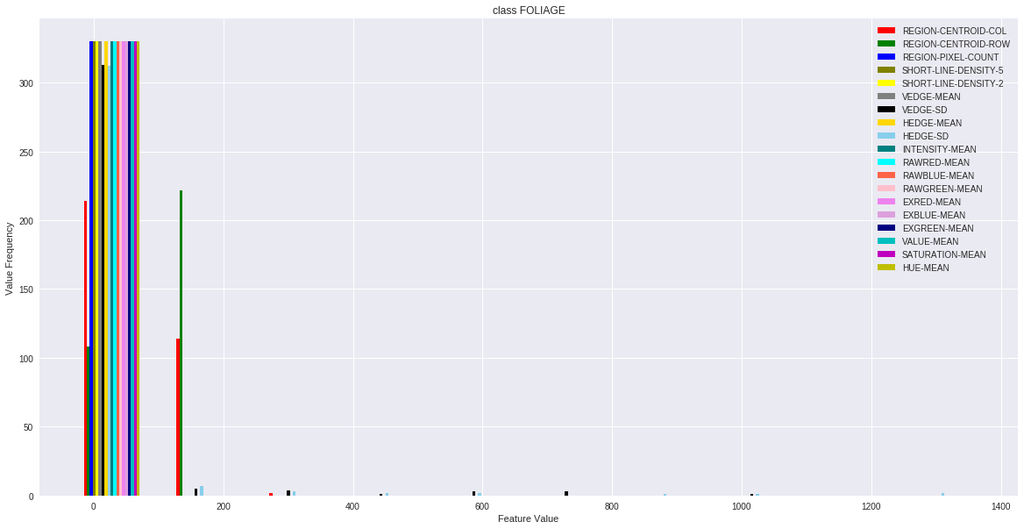

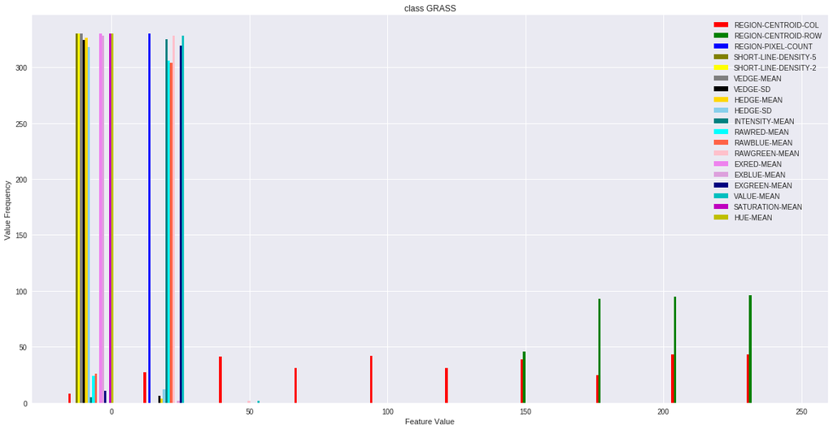

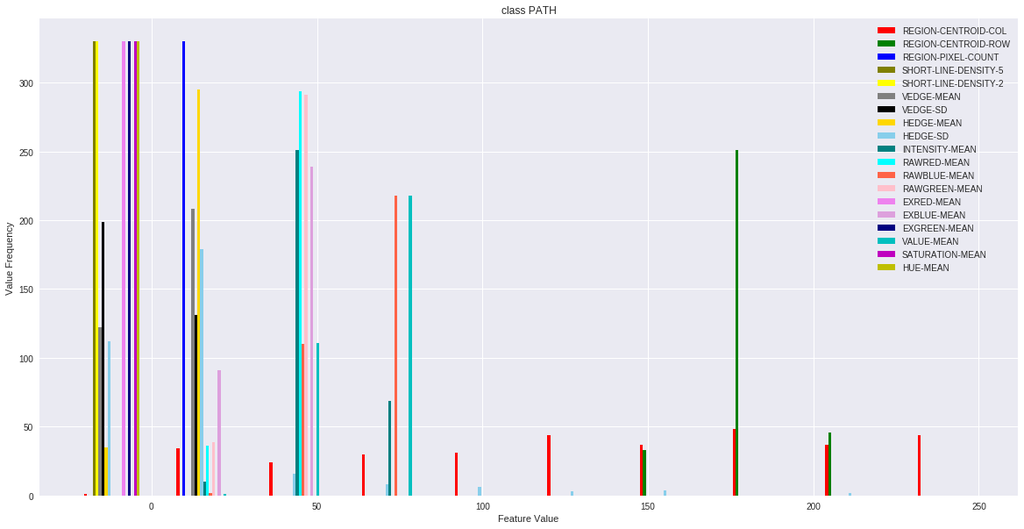

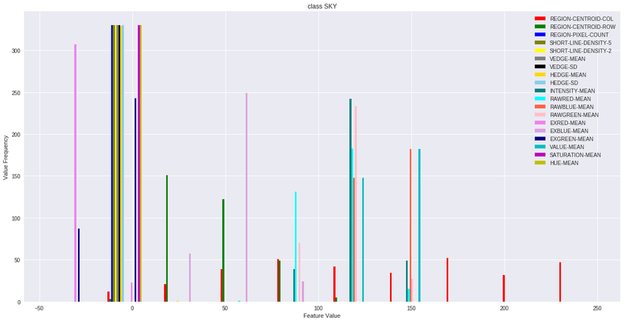

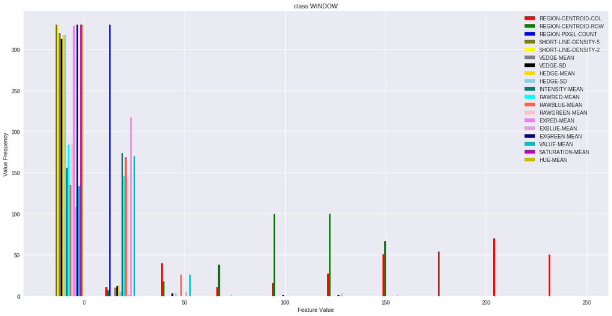

```python
# 10 bins
plot_histogram(10, 0.6)
```

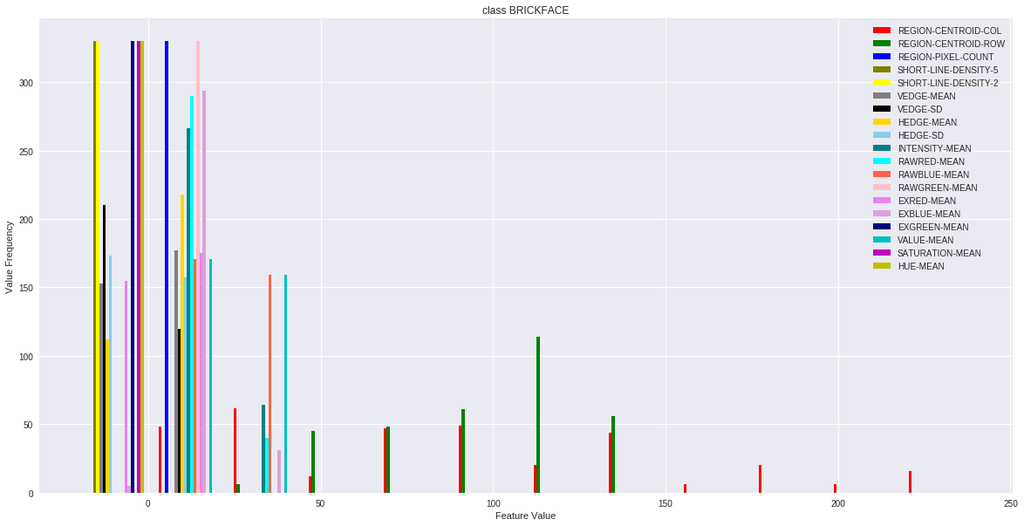

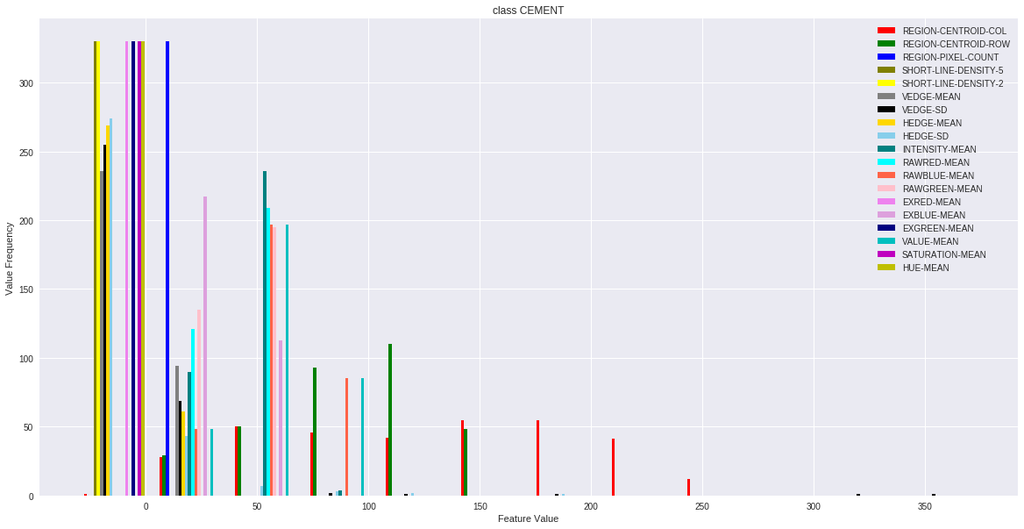

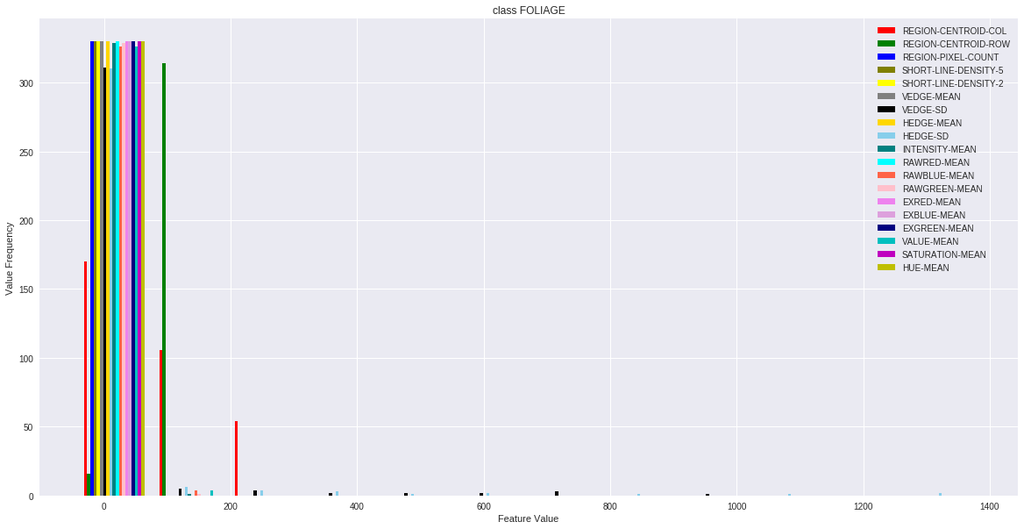

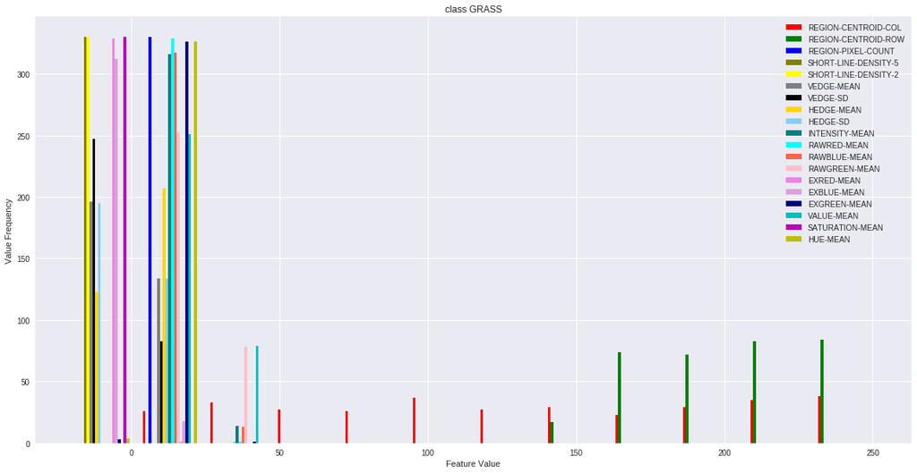

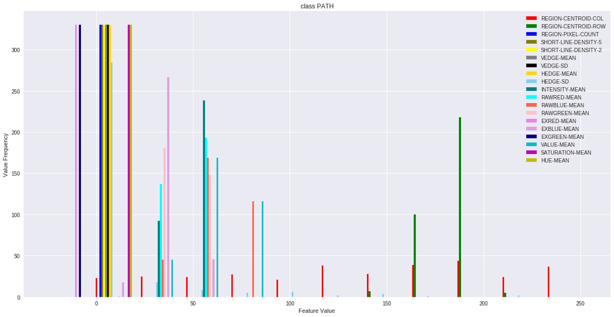

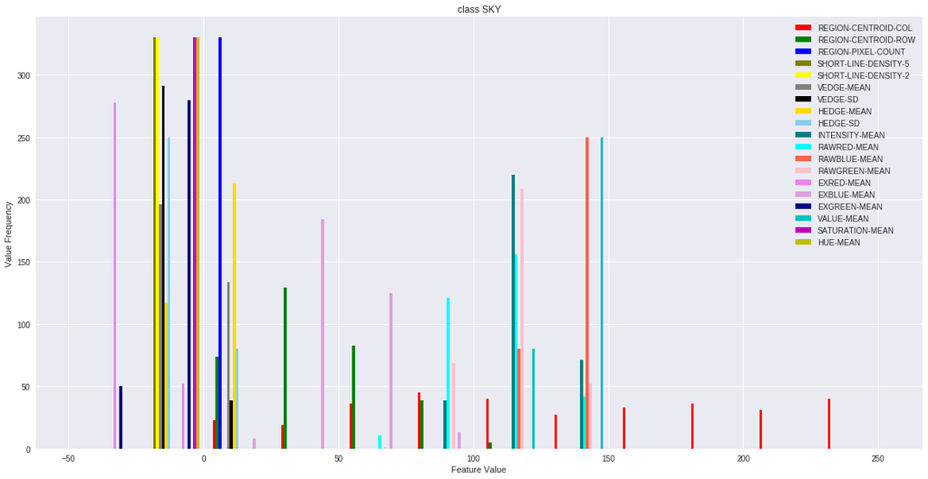

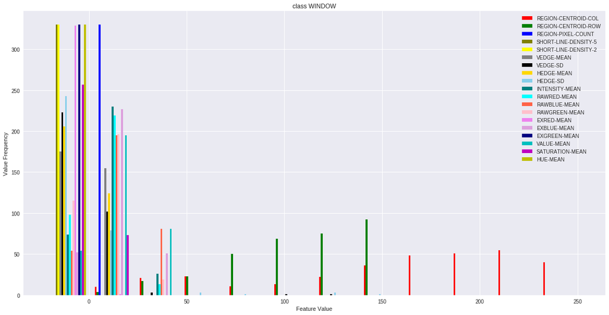

```python
# 12 bins
plot_histogram(12, 0.8)
```

## Normalization

### 1) Min Max Scaler

```python
from sklearn.preprocessing import MinMaxScaler
scaler = MinMaxScaler(feature_range=(0,1))
total_df_normalized_min_max = pd.DataFrame(data=scaler.fit_transform(total_df.iloc[:,1:]), columns=total_df.columns[1:])
display(total_df_normalized_min_max)
```

|  | REGION-CENTROID-COL | REGION-CENTROID-ROW | REGION-PIXEL-COUNT | SHORT-LINE-DENSITY-5 | SHORT-LINE-DENSITY-2 | VEDGE-MEAN | VEDGE-SD | HEDGE-MEAN | HEDGE-SD | INTENSITY-MEAN | RAWRED-MEAN | RAWBLUE-MEAN | RAWGREEN-MEAN | EXRED-MEAN | EXBLUE-MEAN | EXGREEN-MEAN | VALUE-MEAN | SATURATION-MEAN | HUE-MEAN |
| --- | --- | --- | --- | --- | --- | --- | --- | --- | --- | --- | --- | --- | --- | --- | --- | --- | --- | --- | --- |
| 0 | 0.549407 | 0.475000 | 0.0 | 0.000000 | 0.0 | 0.009506 | 0.000063 | 0.014907 | 0.000224 | 0.043119 | 0.053485 | 0.050810 | 0.024942 | 0.891791 | 0.178824 | 0.444023 | 0.051546 | 0.545635 | 0.322724 |
| 1 | 0.739130 | 0.508333 | 0.0 | 0.000000 | 0.0 | 0.011407 | 0.000269 | 0.011180 | 0.000056 | 0.046476 | 0.060778 | 0.051546 | 0.027280 | 0.917910 | 0.167059 | 0.436433 | 0.055965 | 0.538580 | 0.355797 |
| 2 | 0.411067 | 0.533333 | 0.0 | 0.000000 | 0.0 | 0.009506 | 0.000108 | 0.018634 | 0.000377 | 0.042603 | 0.055105 | 0.047865 | 0.024942 | 0.906716 | 0.167059 | 0.447818 | 0.050074 | 0.532628 | 0.348892 |
| 3 | 0.130435 | 0.525000 | 0.0 | 0.000000 | 0.0 | 0.017110 | 0.000168 | 0.024845 | 0.000342 | 0.040795 | 0.056726 | 0.042710 | 0.023383 | 0.930970 | 0.150588 | 0.449715 | 0.051546 | 0.573633 | 0.386107 |
| 4 | 0.150198 | 0.416667 | 0.0 | 0.000000 | 0.0 | 0.024715 | 0.000377 | 0.019876 | 0.000310 | 0.042086 | 0.051053 | 0.050810 | 0.024162 | 0.882463 | 0.183529 | 0.445920 | 0.052283 | 0.562919 | 0.313666 |
| 5 | 0.059289 | 0.487500 | 0.0 | 0.000000 | 0.0 | 0.017110 | 0.000078 | 0.014907 | 0.000224 | 0.038730 | 0.050243 | 0.044183 | 0.021824 | 0.901119 | 0.167059 | 0.453510 | 0.047128 | 0.561508 | 0.345557 |
| 6 | 0.098814 | 0.233333 | 0.0 | 0.333333 | 0.0 | 0.034221 | 0.000896 | 0.054658 | 0.002298 | 0.139427 | 0.142626 | 0.171576 | 0.102104 | 0.811567 | 0.318824 | 0.299810 | 0.171576 | 0.436939 | 0.238552 |
| 7 | 0.051383 | 0.412500 | 0.0 | 0.000000 | 0.0 | 0.058935 | 0.005397 | 0.059627 | 0.000737 | 0.124968 | 0.137763 | 0.142121 | 0.094310 | 0.882463 | 0.243529 | 0.349146 | 0.142121 | 0.368848 | 0.285241 |
| 8 | 0.039526 | 0.404167 | 0.0 | 0.000000 | 0.0 | 0.045627 | 0.000807 | 0.031056 | 0.000687 | 0.123160 | 0.138574 | 0.139912 | 0.090413 | 0.901119 | 0.241176 | 0.333966 | 0.139912 | 0.388756 | 0.292453 |
| 9 | 0.332016 | 0.375000 | 0.0 | 0.000000 | 0.0 | 0.045627 | 0.001300 | 0.028571 | 0.000879 | 0.148464 | 0.154781 | 0.177467 | 0.111458 | 0.830224 | 0.305882 | 0.301708 | 0.177467 | 0.404792 | 0.249398 |
| 10 | 0.067194 | 0.558333 | 0.0 | 0.000000 | 0.0 | 0.013308 | 0.000019 | 0.013665 | 0.000270 | 0.027369 | 0.040519 | 0.026510 | 0.015588 | 0.916045 | 0.134118 | 0.491461 | 0.036819 | 0.600529 | 0.415205 |
| 11 | 0.086957 | 0.183333 | 0.0 | 0.000000 | 0.0 | 0.076046 | 0.003705 | 0.039752 | 0.000566 | 0.163439 | 0.158023 | 0.206186 | 0.123149 | 0.744403 | 0.375294 | 0.277040 | 0.206186 | 0.435070 | 0.213713 |
| 12 | 0.770751 | 0.491667 | 0.0 | 0.000000 | 0.0 | 0.028517 | 0.000437 | 0.014907 | 0.000128 | 0.044152 | 0.057536 | 0.048601 | 0.026500 | 0.912313 | 0.163529 | 0.447818 | 0.054492 | 0.540123 | 0.354459 |
| 13 | 0.312253 | 0.437500 | 0.0 | 0.000000 | 0.0 | 0.051331 | 0.001647 | 0.034783 | 0.000630 | 0.151304 | 0.154781 | 0.182621 | 0.114575 | 0.809701 | 0.317647 | 0.303605 | 0.182621 | 0.407364 | 0.237034 |
| 14 | 0.003953 | 0.137500 | 0.0 | 0.000000 | 0.0 | 0.074145 | 0.002409 | 0.053416 | 0.001103 | 0.130648 | 0.126418 | 0.167158 | 0.095869 | 0.763060 | 0.337647 | 0.318786 | 0.167158 | 0.457681 | 0.216640 |
| 15 | 0.470356 | 0.520833 | 0.0 | 0.000000 | 0.0 | 0.020913 | 0.000422 | 0.022360 | 0.000321 | 0.043635 | 0.056726 | 0.047865 | 0.026500 | 0.910448 | 0.162353 | 0.451613 | 0.053019 | 0.529541 | 0.355832 |
| 16 | 0.573123 | 0.470833 | 0.0 | 0.000000 | 0.0 | 0.017110 | 0.000168 | 0.008696 | 0.000077 | 0.042086 | 0.054295 | 0.048601 | 0.023383 | 0.904851 | 0.172941 | 0.440228 | 0.050810 | 0.563492 | 0.339023 |
| 17 | 0.086957 | 0.308333 | 0.0 | 0.000000 | 0.0 | 0.049430 | 0.001061 | 0.039752 | 0.000695 | 0.125226 | 0.137763 | 0.145066 | 0.091972 | 0.880597 | 0.256471 | 0.330171 | 0.145066 | 0.399751 | 0.278228 |
| 18 | 0.541502 | 0.437500 | 0.0 | 0.000000 | 0.0 | 0.020913 | 0.000153 | 0.009938 | 0.000150 | 0.045185 | 0.055105 | 0.054492 | 0.025721 | 0.888060 | 0.187059 | 0.434535 | 0.055228 | 0.559171 | 0.311098 |
| 19 | 0.901186 | 0.470833 | 0.0 | 0.000000 | 0.0 | 0.030418 | 0.000075 | 0.019876 | 0.000246 | 0.041053 | 0.051864 | 0.047128 | 0.024162 | 0.895522 | 0.170588 | 0.453510 | 0.050074 | 0.545855 | 0.336852 |
| 20 | 0.083004 | 0.437500 | 0.0 | 0.000000 | 0.0 | 0.013308 | 0.000108 | 0.007453 | 0.000096 | 0.039246 | 0.049433 | 0.046392 | 0.021824 | 0.891791 | 0.175294 | 0.449715 | 0.048601 | 0.575397 | 0.326450 |
| 21 | 0.474308 | 0.204167 | 0.0 | 0.000000 | 0.0 | 0.077947 | 0.002349 | 0.064596 | 0.002073 | 0.186419 | 0.179903 | 0.233432 | 0.142634 | 0.729478 | 0.401176 | 0.250474 | 0.233432 | 0.422300 | 0.212882 |
| 22 | 0.126482 | 0.575000 | 0.0 | 0.000000 | 0.0 | 0.019011 | 0.000254 | 0.016149 | 0.000110 | 0.037955 | 0.029984 | 0.057437 | 0.024942 | 0.766791 | 0.234118 | 0.481973 | 0.057437 | 0.578339 | 0.177696 |
| 23 | 0.312253 | 0.350000 | 0.0 | 0.000000 | 0.0 | 0.041825 | 0.001016 | 0.021118 | 0.000398 | 0.149238 | 0.155592 | 0.176730 | 0.113796 | 0.830224 | 0.298824 | 0.313093 | 0.176730 | 0.390436 | 0.247932 |
| 24 | 0.375494 | 0.304167 | 0.0 | 0.000000 | 0.0 | 0.051331 | 0.001288 | 0.036025 | 0.001648 | 0.166279 | 0.171799 | 0.198822 | 0.126267 | 0.819030 | 0.327059 | 0.278937 | 0.198822 | 0.398791 | 0.242638 |
| 25 | 0.569170 | 0.379167 | 0.0 | 0.000000 | 0.0 | 0.030418 | 0.000612 | 0.058385 | 0.001071 | 0.160857 | 0.161264 | 0.197349 | 0.121590 | 0.785448 | 0.344706 | 0.284630 | 0.197349 | 0.417763 | 0.228104 |
| 26 | 0.067194 | 0.529167 | 0.0 | 0.000000 | 0.0 | 0.030418 | 0.000568 | 0.018634 | 0.000216 | 0.040021 | 0.053485 | 0.043446 | 0.023383 | 0.914179 | 0.157647 | 0.455408 | 0.048601 | 0.543871 | 0.366324 |
| 27 | 0.541502 | 0.508333 | 0.0 | 0.000000 | 0.0 | 0.022814 | 0.000448 | 0.026087 | 0.000152 | 0.044926 | 0.056726 | 0.052283 | 0.025721 | 0.901119 | 0.177647 | 0.436433 | 0.054492 | 0.558201 | 0.330138 |
| 28 | 0.474308 | 0.425000 | 0.0 | 0.000000 | 0.0 | 0.058935 | 0.001542 | 0.065838 | 0.001103 | 0.141234 | 0.145867 | 0.168630 | 0.107560 | 0.820896 | 0.296471 | 0.326376 | 0.168630 | 0.396589 | 0.244863 |
| 29 | 0.371542 | 0.191667 | 0.0 | 0.000000 | 0.0 | 0.062738 | 0.003440 | 0.047205 | 0.001240 | 0.183320 | 0.179903 | 0.228277 | 0.138737 | 0.751866 | 0.390588 | 0.244782 | 0.228277 | 0.425691 | 0.219109 |
| ... | ... | ... | ... | ... | ... | ... | ... | ... | ... | ... | ... | ... | ... | ... | ... | ... | ... | ... | ... |
| 2280 | 0.181818 | 0.741667 | 0.0 | 0.000000 | 0.0 | 0.077947 | 0.004590 | 0.131677 | 0.010537 | 0.206558 | 0.195300 | 0.242268 | 0.179267 | 0.690299 | 0.351765 | 0.370019 | 0.242268 | 0.297413 | 0.182922 |
| 2281 | 0.557312 | 0.712500 | 0.0 | 0.000000 | 0.0 | 0.085551 | 0.001109 | 0.050932 | 0.002610 | 0.240640 | 0.230146 | 0.279823 | 0.208885 | 0.684701 | 0.376471 | 0.335863 | 0.279823 | 0.293208 | 0.184858 |
| 2282 | 0.980237 | 0.595833 | 0.0 | 0.000000 | 0.5 | 0.144487 | 0.018315 | 0.038509 | 0.002290 | 0.029951 | 0.018639 | 0.050810 | 0.018706 | 0.746269 | 0.238824 | 0.495256 | 0.050810 | 0.815344 | 0.159211 |
| 2283 | 0.596838 | 0.587500 | 0.0 | 0.000000 | 0.0 | 0.005703 | 0.000034 | 0.047205 | 0.003131 | 0.009812 | 0.007293 | 0.016200 | 0.005456 | 0.813433 | 0.164706 | 0.546490 | 0.016200 | 0.439153 | 0.175250 |
| 2284 | 0.588933 | 0.587500 | 0.0 | 0.000000 | 0.0 | 0.003802 | 0.000030 | 0.045963 | 0.002578 | 0.009553 | 0.007293 | 0.015464 | 0.005456 | 0.815299 | 0.162353 | 0.548387 | 0.015464 | 0.537037 | 0.174061 |
| 2285 | 0.474308 | 0.595833 | 0.0 | 0.000000 | 0.0 | 0.015209 | 0.000120 | 0.058385 | 0.004149 | 0.012910 | 0.011345 | 0.019882 | 0.007015 | 0.819030 | 0.168235 | 0.535104 | 0.019882 | 0.534392 | 0.191089 |
| 2286 | 0.588933 | 0.587500 | 0.0 | 0.000000 | 0.0 | 0.003802 | 0.000030 | 0.045963 | 0.002578 | 0.009553 | 0.007293 | 0.015464 | 0.005456 | 0.815299 | 0.162353 | 0.548387 | 0.015464 | 0.537037 | 0.174061 |
| 2287 | 0.830040 | 0.595833 | 0.0 | 0.000000 | 0.0 | 0.003802 | 0.000030 | 0.008696 | 0.000045 | 0.001807 | 0.000000 | 0.005155 | 0.000000 | 0.820896 | 0.148235 | 0.565465 | 0.005155 | 0.555556 | 0.159449 |
| 2288 | 0.679842 | 0.587500 | 0.0 | 0.000000 | 0.0 | 0.007605 | 0.000030 | 0.018634 | 0.000120 | 0.025045 | 0.019449 | 0.038292 | 0.016368 | 0.787313 | 0.201176 | 0.514232 | 0.038292 | 0.599735 | 0.175666 |
| 2289 | 0.094862 | 0.600000 | 0.0 | 0.000000 | 0.0 | 0.195818 | 0.100585 | 0.402484 | 0.109418 | 0.099923 | 0.094814 | 0.123711 | 0.079501 | 0.766791 | 0.269412 | 0.425047 | 0.142121 | 0.646298 | 0.209302 |
| 2290 | 0.845850 | 0.591667 | 0.0 | 0.000000 | 0.5 | 0.673004 | 0.008112 | 0.024845 | 0.002811 | 0.058094 | 0.038898 | 0.089102 | 0.043648 | 0.682836 | 0.294118 | 0.470588 | 0.089102 | 0.769577 | 0.151139 |
| 2291 | 0.869565 | 0.595833 | 0.0 | 0.333333 | 0.5 | 0.144487 | 0.002764 | 0.028571 | 0.000430 | 0.045185 | 0.031605 | 0.071429 | 0.030398 | 0.725746 | 0.268235 | 0.468691 | 0.071429 | 0.624800 | 0.160525 |
| 2292 | 0.569170 | 0.600000 | 0.0 | 0.000000 | 0.5 | 0.169202 | 0.035916 | 0.222360 | 0.087567 | 0.078750 | 0.056726 | 0.116348 | 0.060016 | 0.656716 | 0.330588 | 0.438330 | 0.116348 | 0.747294 | 0.151703 |
| 2293 | 0.256917 | 0.600000 | 0.0 | 0.000000 | 0.0 | 0.127376 | 0.021978 | 0.172671 | 0.051628 | 0.057578 | 0.042950 | 0.083947 | 0.043648 | 0.714552 | 0.271765 | 0.474383 | 0.083947 | 0.300624 | 0.150513 |
| 2294 | 0.177866 | 0.595833 | 0.0 | 0.333333 | 0.0 | 0.108365 | 0.008280 | 0.036025 | 0.000879 | 0.044410 | 0.070502 | 0.030928 | 0.033515 | 1.000000 | 0.077647 | 0.497154 | 0.064065 | 0.561927 | 0.510227 |
| 2295 | 0.335968 | 0.600000 | 0.0 | 0.000000 | 0.0 | 0.146388 | 0.010640 | 0.120497 | 0.043453 | 0.060935 | 0.048622 | 0.085420 | 0.046765 | 0.729478 | 0.263529 | 0.472486 | 0.085420 | 0.392385 | 0.161983 |
| 2296 | 0.976285 | 0.591667 | 0.0 | 0.000000 | 0.0 | 0.009506 | 0.000063 | 0.002484 | 0.000021 | 0.002582 | 0.000000 | 0.007364 | 0.000000 | 0.815299 | 0.155294 | 0.559772 | 0.007364 | 0.888889 | 0.159449 |
| 2297 | 0.818182 | 0.595833 | 0.0 | 0.000000 | 0.5 | 0.399240 | 0.126918 | 0.021118 | 0.000494 | 0.060676 | 0.042950 | 0.092047 | 0.044427 | 0.692164 | 0.296471 | 0.457306 | 0.092047 | 0.771517 | 0.164062 |
| 2298 | 0.166008 | 0.587500 | 0.0 | 0.000000 | 0.0 | 0.066540 | 0.001722 | 0.027329 | 0.000598 | 0.010586 | 0.007293 | 0.019146 | 0.004677 | 0.807836 | 0.175294 | 0.535104 | 0.019146 | 0.648677 | 0.186503 |
| 2299 | 0.019763 | 0.595833 | 0.0 | 0.000000 | 0.0 | 0.003802 | 0.000030 | 0.002484 | 0.000021 | 0.000516 | 0.000000 | 0.001473 | 0.000000 | 0.830224 | 0.136471 | 0.574953 | 0.001473 | 0.222222 | 0.159449 |
| 2300 | 0.596838 | 0.600000 | 0.0 | 0.000000 | 0.0 | 0.017110 | 0.000616 | 0.240994 | 0.095077 | 0.050865 | 0.038898 | 0.072901 | 0.038971 | 0.735075 | 0.249412 | 0.489564 | 0.072901 | 0.500000 | 0.155894 |
| 2301 | 0.308300 | 0.595833 | 0.0 | 0.000000 | 0.0 | 0.038023 | 0.001598 | 0.003727 | 0.000056 | 0.005164 | 0.003241 | 0.010309 | 0.001559 | 0.819030 | 0.157647 | 0.552182 | 0.010309 | 0.288889 | 0.188786 |
| 2302 | 0.652174 | 0.595833 | 0.0 | 0.000000 | 0.0 | 0.003802 | 0.000030 | 0.009938 | 0.000053 | 0.004906 | 0.001621 | 0.012518 | 0.000000 | 0.809701 | 0.169412 | 0.542695 | 0.012518 | 1.000000 | 0.172356 |
| 2303 | 0.679842 | 0.612500 | 0.0 | 0.333333 | 0.0 | 0.064639 | 0.003705 | 0.026087 | 0.000345 | 0.058353 | 0.051864 | 0.078056 | 0.043648 | 0.770522 | 0.240000 | 0.468691 | 0.078056 | 0.472975 | 0.191303 |
| 2304 | 0.916996 | 0.616667 | 0.0 | 0.000000 | 0.0 | 0.085551 | 0.000527 | 0.028571 | 0.001135 | 0.046217 | 0.037277 | 0.067010 | 0.032736 | 0.757463 | 0.242353 | 0.478178 | 0.067010 | 0.541667 | 0.175389 |
| 2305 | 0.122530 | 0.612500 | 0.0 | 0.000000 | 0.0 | 0.032319 | 0.000870 | 0.018634 | 0.000441 | 0.055513 | 0.046191 | 0.078792 | 0.039751 | 0.751866 | 0.256471 | 0.461101 | 0.078792 | 0.520578 | 0.178177 |
| 2306 | 0.027668 | 0.629167 | 0.0 | 0.333333 | 0.0 | 0.055133 | 0.002080 | 0.007453 | 0.000096 | 0.058353 | 0.048622 | 0.079529 | 0.045207 | 0.748134 | 0.247059 | 0.480076 | 0.079529 | 0.484805 | 0.167750 |
| 2307 | 0.501976 | 0.625000 | 0.0 | 0.000000 | 0.0 | 0.019011 | 0.000254 | 0.017391 | 0.000118 | 0.049832 | 0.040519 | 0.072165 | 0.035074 | 0.753731 | 0.250588 | 0.468691 | 0.072165 | 0.540918 | 0.175915 |
| 2308 | 0.588933 | 0.612500 | 0.0 | 0.000000 | 0.0 | 0.074145 | 0.001647 | 0.031056 | 0.000302 | 0.058869 | 0.051053 | 0.081001 | 0.042868 | 0.761194 | 0.251765 | 0.459203 | 0.081001 | 0.503086 | 0.184789 |
| 2309 | 0.486166 | 0.629167 | 0.0 | 0.333333 | 0.0 | 0.047529 | 0.001139 | 0.044720 | 0.000641 | 0.069972 | 0.058347 | 0.096465 | 0.053001 | 0.731343 | 0.275294 | 0.451613 | 0.096465 | 0.479931 | 0.170375 |

2310 rows × 19 columns

Visualizing data after normalization by Min Max Scaler

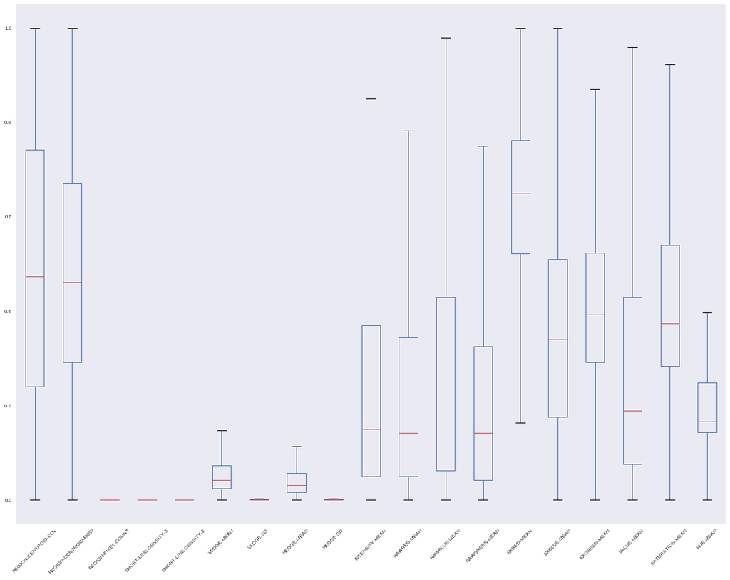

```python
fig = plt.figure(figsize = (20,15))
boxplot = total_df_normalized_min_max.boxplot(grid=False, fontsize=8, rot=45)
```

**Comment** : After Min Max Normalization we could see that data is not skewed much. So all attribute now have nearly the same range and we can extract patters/insights from the data easily. Moreover, we can see the correlation between the attributes.

### 2) Z Score Normalization

Finding Z Score Normalization for all attributes

```python
from scipy.stats import zscore
total_df_normalized_zscore1 = total_df.iloc[:,1:].apply(zscore)
display(total_df_normalized_zscore1)
```

|  | REGION-CENTROID-COL | REGION-CENTROID-ROW | REGION-PIXEL-COUNT | SHORT-LINE-DENSITY-5 | SHORT-LINE-DENSITY-2 | VEDGE-MEAN | VEDGE-SD | HEDGE-MEAN | HEDGE-SD | INTENSITY-MEAN | RAWRED-MEAN | RAWBLUE-MEAN | RAWGREEN-MEAN | EXRED-MEAN | EXBLUE-MEAN | EXGREEN-MEAN | VALUE-MEAN | SATURATION-MEAN | HUE-MEAN |
| --- | --- | --- | --- | --- | --- | --- | --- | --- | --- | --- | --- | --- | --- | --- | --- | --- | --- | --- | --- |
| 0 | 0.206827 | 0.027539 | NaN | -0.357047 | -0.194552 | -0.598950 | -0.125931 | -0.487090 | -0.134911 | -0.808696 | -0.727621 | -0.839220 | -0.841382 | 1.393250 | -0.866965 | 0.071789 | -0.870602 | 0.520205 | 0.156038 |
| 1 | 0.864896 | 0.166738 | NaN | -0.357047 | -0.194552 | -0.578361 | -0.121388 | -0.533267 | -0.138879 | -0.796081 | -0.699073 | -0.836667 | -0.832214 | 1.527569 | -0.923748 | 0.033306 | -0.855067 | 0.489298 | 0.283547 |
| 2 | -0.273014 | 0.271138 | NaN | -0.357047 | -0.194552 | -0.598950 | -0.124940 | -0.440914 | -0.131320 | -0.810636 | -0.721277 | -0.849433 | -0.841382 | 1.470004 | -0.923748 | 0.091031 | -0.875781 | 0.463221 | 0.256926 |
| 3 | -1.246407 | 0.236338 | NaN | -0.357047 | -0.194552 | -0.516594 | -0.123619 | -0.363952 | -0.132139 | -0.817429 | -0.714933 | -0.867306 | -0.847494 | 1.594729 | -1.003245 | 0.100651 | -0.870602 | 0.642864 | 0.400405 |
| 4 | -1.177858 | -0.216061 | NaN | -0.357047 | -0.194552 | -0.434239 | -0.118993 | -0.425521 | -0.132895 | -0.812577 | -0.737137 | -0.839220 | -0.844438 | 1.345279 | -0.844252 | 0.081410 | -0.868013 | 0.595925 | 0.121116 |
| 5 | -1.493183 | 0.079739 | NaN | -0.357047 | -0.194552 | -0.516595 | -0.125601 | -0.487090 | -0.134911 | -0.825192 | -0.740309 | -0.862199 | -0.853607 | 1.441221 | -0.923748 | 0.119893 | -0.886138 | 0.589744 | 0.244069 |
| 6 | -1.356085 | -0.981659 | NaN | 2.410668 | -0.194552 | -0.331294 | -0.107511 | 0.005464 | -0.086031 | -0.446749 | -0.378706 | -0.420492 | -0.538826 | 0.980699 | -0.191244 | -0.659387 | -0.448554 | 0.044012 | -0.168482 |
| 7 | -1.520602 | -0.233461 | NaN | -0.357047 | -0.194552 | -0.063638 | -0.007973 | 0.067033 | -0.122817 | -0.501090 | -0.397737 | -0.522621 | -0.569387 | 1.345279 | -0.554657 | -0.409248 | -0.552124 | -0.254292 | 0.011522 |
| 8 | -1.561732 | -0.268261 | NaN | -0.357047 | -0.194552 | -0.207761 | -0.109493 | -0.286990 | -0.124013 | -0.507882 | -0.394565 | -0.530281 | -0.584668 | 1.441221 | -0.566014 | -0.486214 | -0.559892 | -0.167075 | 0.039329 |
| 9 | -0.547209 | -0.390060 | NaN | -0.357047 | -0.194552 | -0.207761 | -0.098589 | -0.317775 | -0.119478 | -0.412787 | -0.331126 | -0.400066 | -0.502153 | 1.076641 | -0.253706 | -0.649766 | -0.427840 | -0.096823 | -0.126668 |
| 10 | -1.465763 | 0.375538 | NaN | -0.357047 | -0.194552 | -0.557772 | -0.126923 | -0.502483 | -0.133840 | -0.867888 | -0.778372 | -0.923476 | -0.878056 | 1.517975 | -1.082741 | 0.312307 | -0.922387 | 0.760695 | 0.512593 |
| 11 | -1.397214 | -1.190458 | NaN | -0.357047 | -0.194552 | 0.121662 | -0.045392 | -0.179244 | -0.126848 | -0.356505 | -0.318438 | -0.300491 | -0.456311 | 0.635307 | 0.081316 | -0.774836 | -0.326860 | 0.035824 | -0.264250 |
| 12 | 0.974574 | 0.097138 | NaN | -0.357047 | -0.194552 | -0.393061 | -0.117671 | -0.487090 | -0.137178 | -0.804814 | -0.711761 | -0.846880 | -0.835270 | 1.498787 | -0.940783 | 0.091031 | -0.860245 | 0.496059 | 0.278391 |
| 13 | -0.615758 | -0.129061 | NaN | -0.357047 | -0.194552 | -0.145994 | -0.090907 | -0.240813 | -0.125336 | -0.402113 | -0.331126 | -0.382194 | -0.489928 | 0.971105 | -0.196922 | -0.640145 | -0.409716 | -0.085555 | -0.174334 |
| 14 | -1.685119 | -1.381858 | NaN | -0.357047 | -0.194552 | 0.101073 | -0.074056 | -0.009928 | -0.114187 | -0.479742 | -0.442145 | -0.435811 | -0.563275 | 0.731249 | -0.100391 | -0.563180 | -0.464090 | 0.134883 | -0.252963 |
| 15 | -0.067368 | 0.218938 | NaN | -0.357047 | -0.194552 | -0.475417 | -0.118001 | -0.394736 | -0.132643 | -0.806755 | -0.714933 | -0.849433 | -0.835270 | 1.489192 | -0.946461 | 0.110272 | -0.865424 | 0.449700 | 0.283683 |
| 16 | 0.289086 | 0.010139 | NaN | -0.357047 | -0.194552 | -0.516595 | -0.123619 | -0.564052 | -0.138375 | -0.812577 | -0.724449 | -0.846880 | -0.847494 | 1.460410 | -0.895356 | 0.052548 | -0.873191 | 0.598436 | 0.218878 |
| 17 | -1.397214 | -0.668460 | NaN | -0.357047 | -0.194552 | -0.166583 | -0.103876 | -0.179244 | -0.123824 | -0.500119 | -0.397737 | -0.512408 | -0.578556 | 1.335685 | -0.492195 | -0.505455 | -0.541767 | -0.118906 | -0.015515 |
| 18 | 0.179408 | -0.129061 | NaN | -0.357047 | -0.194552 | -0.475417 | -0.123949 | -0.548660 | -0.136674 | -0.800933 | -0.721277 | -0.826454 | -0.838326 | 1.374062 | -0.827217 | 0.023685 | -0.857656 | 0.579506 | 0.111215 |
| 19 | 1.426996 | 0.010139 | NaN | -0.357047 | -0.194552 | -0.372472 | -0.125684 | -0.425521 | -0.134407 | -0.816458 | -0.733965 | -0.851986 | -0.844438 | 1.412439 | -0.906713 | 0.119893 | -0.875781 | 0.521171 | 0.210508 |
| 20 | -1.410924 | -0.129061 | NaN | -0.357047 | -0.194552 | -0.557772 | -0.124940 | -0.579444 | -0.137934 | -0.823251 | -0.743481 | -0.854539 | -0.853607 | 1.393250 | -0.884000 | 0.100651 | -0.880959 | 0.650591 | 0.170403 |
| 21 | -0.053658 | -1.103459 | NaN | -0.357047 | -0.194552 | 0.142251 | -0.075378 | 0.128603 | -0.091322 | -0.270143 | -0.232796 | -0.206022 | -0.379908 | 0.558554 | 0.206239 | -0.909526 | -0.231058 | -0.020121 | -0.267454 |
| 22 | -1.260117 | 0.445138 | NaN | -0.357047 | -0.194552 | -0.496006 | -0.121719 | -0.471698 | -0.137619 | -0.828103 | -0.819608 | -0.816241 | -0.841382 | 0.750438 | -0.600084 | 0.264204 | -0.849888 | 0.663480 | -0.403110 |
| 23 | -0.615758 | -0.494460 | NaN | -0.357047 | -0.194552 | -0.248939 | -0.104867 | -0.410129 | -0.130816 | -0.409875 | -0.327954 | -0.402620 | -0.492984 | 1.076641 | -0.287776 | -0.592042 | -0.430430 | -0.159717 | -0.132317 |
| 24 | -0.396402 | -0.685860 | NaN | -0.357047 | -0.194552 | -0.145994 | -0.098837 | -0.225421 | -0.101337 | -0.345831 | -0.264515 | -0.326023 | -0.444086 | 1.019076 | -0.151496 | -0.765215 | -0.352752 | -0.123114 | -0.152731 |
| 25 | 0.275376 | -0.372660 | NaN | -0.357047 | -0.194552 | -0.372472 | -0.113789 | 0.051641 | -0.114943 | -0.366209 | -0.305751 | -0.331129 | -0.462423 | 0.846380 | -0.066321 | -0.736353 | -0.357931 | -0.040000 | -0.208766 |
| 26 | -1.465763 | 0.253738 | NaN | -0.357047 | -0.194552 | -0.372472 | -0.114780 | -0.440914 | -0.135100 | -0.820340 | -0.727621 | -0.864752 | -0.847494 | 1.508381 | -0.969175 | 0.129513 | -0.880959 | 0.512478 | 0.324135 |
| 27 | 0.179408 | 0.166738 | NaN | -0.357047 | -0.194552 | -0.454828 | -0.117423 | -0.348560 | -0.136611 | -0.801903 | -0.714933 | -0.834114 | -0.838326 | 1.441221 | -0.872643 | 0.033306 | -0.860245 | 0.575257 | 0.184620 |
| 28 | -0.053658 | -0.181261 | NaN | -0.357047 | -0.194552 | -0.063639 | -0.093220 | 0.143995 | -0.114187 | -0.439957 | -0.366018 | -0.430705 | -0.517433 | 1.028670 | -0.299132 | -0.524697 | -0.458911 | -0.132761 | -0.144150 |
| 29 | -0.410112 | -1.155658 | NaN | -0.357047 | -0.194552 | -0.022461 | -0.051257 | -0.086890 | -0.110975 | -0.281787 | -0.232796 | -0.223894 | -0.395188 | 0.673684 | 0.155134 | -0.938388 | -0.249182 | -0.005266 | -0.243444 |
| ... | ... | ... | ... | ... | ... | ... | ... | ... | ... | ... | ... | ... | ... | ... | ... | ... | ... | ... | ... |
| 2070 | -1.068180 | 1.141136 | NaN | -0.357047 | -0.194552 | 0.142251 | -0.025815 | 0.959788 | 0.108229 | -0.194454 | -0.172528 | -0.175383 | -0.236270 | 0.357075 | -0.032251 | -0.303420 | -0.199986 | -0.567248 | -0.382962 |
| 2071 | 0.234247 | 1.019336 | NaN | -0.357047 | -0.194552 | 0.224606 | -0.102802 | -0.040713 | -0.078661 | -0.066366 | -0.036134 | -0.045169 | -0.120137 | 0.328292 | 0.086994 | -0.476593 | -0.067935 | -0.585671 | -0.375496 |
| 2072 | 1.701191 | 0.532137 | NaN | -0.357047 | 4.391310 | 0.862863 | 0.277755 | -0.194636 | -0.086220 | -0.858184 | -0.864015 | -0.839220 | -0.865831 | 0.644901 | -0.577370 | 0.331549 | -0.873191 | 1.701792 | -0.474379 |
| 2073 | 0.371345 | 0.497337 | NaN | -0.357047 | -0.194552 | -0.640128 | -0.126592 | -0.086890 | -0.066378 | -0.933873 | -0.908423 | -0.959221 | -0.917785 | 0.990293 | -0.935105 | 0.591309 | -0.994886 | 0.053713 | -0.412540 |
| 2074 | 0.343925 | 0.497337 | NaN | -0.357047 | -0.194552 | -0.660717 | -0.126675 | -0.102282 | -0.079417 | -0.934843 | -0.908423 | -0.961775 | -0.917785 | 0.999887 | -0.946461 | 0.600930 | -0.997475 | 0.482538 | -0.417122 |
| 2075 | -0.053658 | 0.532137 | NaN | -0.357047 | -0.194552 | -0.537183 | -0.124692 | 0.051641 | -0.042379 | -0.922228 | -0.892563 | -0.946455 | -0.911673 | 1.019076 | -0.918070 | 0.533584 | -0.981940 | 0.470948 | -0.351475 |
| 2076 | 0.343925 | 0.497337 | NaN | -0.357047 | -0.194552 | -0.660717 | -0.126675 | -0.102282 | -0.079417 | -0.934843 | -0.908423 | -0.961775 | -0.917785 | 0.999887 | -0.946461 | 0.600930 | -0.997475 | 0.482538 | -0.417122 |
| 2077 | 1.180220 | 0.532137 | NaN | -0.357047 | -0.194552 | -0.660717 | -0.126675 | -0.564052 | -0.139131 | -0.963954 | -0.936970 | -0.997520 | -0.939178 | 1.028670 | -1.014601 | 0.687516 | -1.033725 | 0.563667 | -0.473461 |
| 2078 | 0.659250 | 0.497337 | NaN | -0.357047 | -0.194552 | -0.619539 | -0.126675 | -0.440914 | -0.137367 | -0.876621 | -0.860843 | -0.882625 | -0.874999 | 0.855974 | -0.759077 | 0.427756 | -0.917209 | 0.757218 | -0.410938 |
| 2079 | -1.369795 | 0.549537 | NaN | -0.357047 | -0.194552 | 1.418764 | 2.097444 | 4.315315 | 2.439594 | -0.595215 | -0.565851 | -0.586451 | -0.627454 | 0.750438 | -0.429734 | -0.024418 | -0.552124 | 0.961207 | -0.281254 |
| 2080 | 1.235059 | 0.514737 | NaN | -0.357047 | 4.391310 | 6.586581 | 0.052081 | -0.363952 | -0.073937 | -0.752414 | -0.784716 | -0.706453 | -0.768035 | 0.318698 | -0.310489 | 0.206479 | -0.738550 | 1.501287 | -0.505497 |
| 2081 | 1.317318 | 0.532137 | NaN | 2.410668 | 4.391310 | 0.862863 | -0.066209 | -0.317775 | -0.130060 | -0.800933 | -0.813264 | -0.767730 | -0.819989 | 0.539365 | -0.435412 | 0.196859 | -0.800692 | 0.867025 | -0.469312 |
| 2082 | 0.275376 | 0.549537 | NaN | -0.357047 | 4.391310 | 1.130518 | 0.667069 | 2.083428 | 1.924404 | -0.674785 | -0.714933 | -0.611984 | -0.703857 | 0.184379 | -0.134461 | 0.042927 | -0.642748 | 1.403669 | -0.503323 |
| 2083 | -0.807695 | 0.549537 | NaN | -0.357047 | -0.194552 | 0.677562 | 0.358790 | 1.467735 | 1.077069 | -0.754355 | -0.768856 | -0.724325 | -0.768035 | 0.481800 | -0.418377 | 0.225721 | -0.756675 | -0.553182 | -0.507912 |
| 2084 | -1.081890 | 0.532137 | NaN | 2.410668 | -0.194552 | 0.471673 | 0.055798 | -0.225421 | -0.119478 | -0.803844 | -0.661010 | -0.908157 | -0.807765 | 1.949715 | -1.355301 | 0.341170 | -0.826585 | 0.591580 | 0.878944 |
| 2085 | -0.533500 | 0.549537 | NaN | -0.357047 | -0.194552 | 0.883452 | 0.108004 | 0.821257 | 0.884322 | -0.741740 | -0.746653 | -0.719219 | -0.755811 | 0.558554 | -0.458125 | 0.216100 | -0.751497 | -0.151177 | -0.463688 |
| 2086 | 1.687481 | 0.514737 | NaN | -0.357047 | -0.194552 | -0.598950 | -0.125931 | -0.641014 | -0.139698 | -0.961043 | -0.936970 | -0.989860 | -0.939178 | 0.999887 | -0.980531 | 0.658654 | -1.025957 | 2.023990 | -0.473461 |
| 2087 | 1.139091 | 0.532137 | NaN | -0.357047 | 4.391310 | 3.621777 | 2.679886 | -0.410129 | -0.128549 | -0.742711 | -0.768856 | -0.696240 | -0.764979 | 0.366669 | -0.299132 | 0.139134 | -0.728193 | 1.509786 | -0.455675 |
| 2088 | -1.123019 | 0.497337 | NaN | -0.357047 | -0.194552 | 0.018717 | -0.089255 | -0.333167 | -0.126092 | -0.930962 | -0.908423 | -0.949009 | -0.920841 | 0.961511 | -0.884000 | 0.533584 | -0.984529 | 0.971630 | -0.369153 |
| 2089 | -1.630280 | 0.532137 | NaN | -0.357047 | -0.194552 | -0.660717 | -0.126675 | -0.641014 | -0.139698 | -0.968806 | -0.936970 | -1.010286 | -0.939178 | 1.076641 | -1.071385 | 0.735620 | -1.046671 | -0.896656 | -0.473461 |
| 2090 | 0.371345 | 0.549537 | NaN | -0.357047 | -0.194552 | -0.516595 | -0.113706 | 2.314313 | 2.101467 | -0.779585 | -0.784716 | -0.762624 | -0.786372 | 0.587336 | -0.526265 | 0.302687 | -0.795514 | 0.320280 | -0.487165 |
| 2091 | -0.629468 | 0.532137 | NaN | -0.357047 | -0.194552 | -0.290116 | -0.091981 | -0.625621 | -0.138879 | -0.951339 | -0.924282 | -0.979647 | -0.933066 | 1.019076 | -0.969175 | 0.620171 | -1.015600 | -0.604592 | -0.360351 |
| 2092 | 0.563281 | 0.532137 | NaN | -0.357047 | -0.194552 | -0.660717 | -0.126675 | -0.548660 | -0.138942 | -0.952310 | -0.930626 | -0.971988 | -0.939178 | 0.971105 | -0.912391 | 0.572067 | -1.007832 | 2.510764 | -0.423698 |
| 2093 | 0.659250 | 0.601737 | NaN | 2.410668 | -0.194552 | -0.001872 | -0.045392 | -0.348560 | -0.132076 | -0.751444 | -0.733965 | -0.744751 | -0.768035 | 0.769626 | -0.571692 | 0.196859 | -0.777389 | 0.201885 | -0.350650 |
| 2094 | 1.481835 | 0.619137 | NaN | -0.357047 | -0.194552 | 0.224606 | -0.115689 | -0.317775 | -0.113431 | -0.797051 | -0.791060 | -0.783049 | -0.810821 | 0.702467 | -0.560335 | 0.244962 | -0.816228 | 0.502820 | -0.412004 |
| 2095 | -1.273827 | 0.601737 | NaN | -0.357047 | -0.194552 | -0.351883 | -0.108089 | -0.440914 | -0.129808 | -0.762118 | -0.756169 | -0.742198 | -0.783316 | 0.673684 | -0.492195 | 0.158376 | -0.774800 | 0.410432 | -0.401254 |
| 2096 | -1.602861 | 0.671337 | NaN | 2.410668 | -0.194552 | -0.104816 | -0.081325 | -0.579444 | -0.137934 | -0.751444 | -0.746653 | -0.739645 | -0.761923 | 0.654496 | -0.537622 | 0.254583 | -0.772211 | 0.253712 | -0.441456 |
| 2097 | 0.042310 | 0.653937 | NaN | -0.357047 | -0.194552 | -0.496006 | -0.121719 | -0.456306 | -0.137430 | -0.783466 | -0.778372 | -0.765177 | -0.801652 | 0.683278 | -0.520587 | 0.196859 | -0.798103 | 0.499539 | -0.409974 |
| 2098 | 0.343925 | 0.601737 | NaN | -0.357047 | -0.194552 | 0.101073 | -0.090907 | -0.286990 | -0.133084 | -0.749503 | -0.737137 | -0.734538 | -0.771091 | 0.721655 | -0.514909 | 0.148755 | -0.767032 | 0.333801 | -0.375761 |
| 2099 | -0.012529 | 0.671337 | NaN | 2.410668 | -0.194552 | -0.187172 | -0.102141 | -0.117675 | -0.125084 | -0.707778 | -0.708589 | -0.680920 | -0.731362 | 0.568148 | -0.401342 | 0.110272 | -0.712658 | 0.232359 | -0.431336 |

2310 rows × 19 columns

Visualizing data after normalization by Z Score

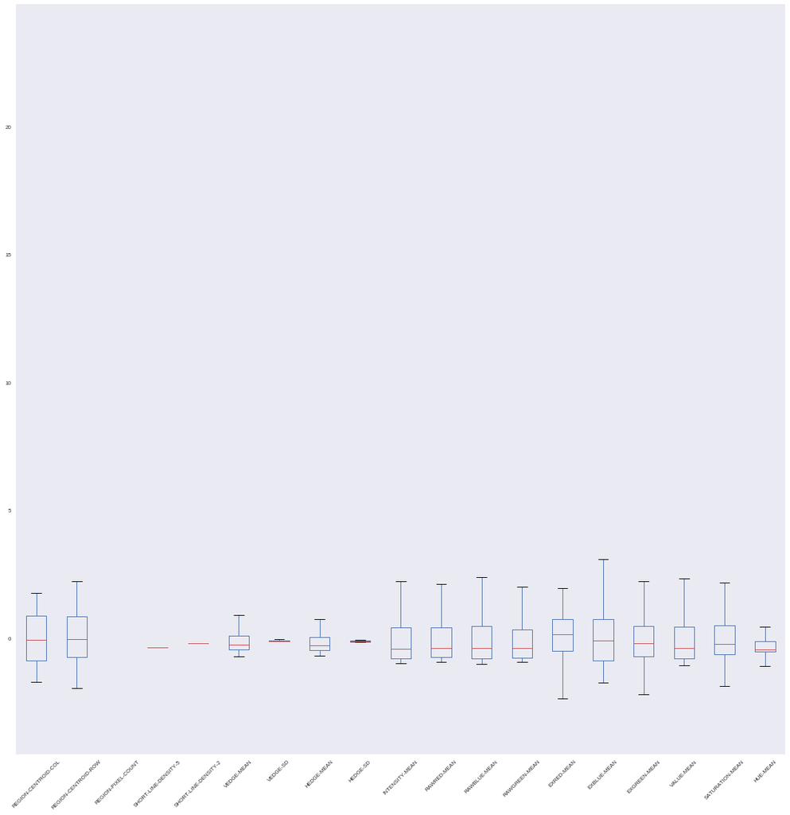

```python
boxplot = total_df_normalized_zscore1.boxplot(grid=False, fontsize=8, rot=45, figsize=(20,20))
```

Finding Z Score Normalization for the non constant attributes to avoid NaN values after the normalization

```python
total_df_normalized_zscore2 = total_df.iloc[:,1:].apply(lambda x: x if np.std(x) == 0 else zscore(x))
display(total_df_normalized_zscore2)
```

|  | REGION-CENTROID-COL | REGION-CENTROID-ROW | REGION-PIXEL-COUNT | SHORT-LINE-DENSITY-5 | SHORT-LINE-DENSITY-2 | VEDGE-MEAN | VEDGE-SD | HEDGE-MEAN | HEDGE-SD | INTENSITY-MEAN | RAWRED-MEAN | RAWBLUE-MEAN | RAWGREEN-MEAN | EXRED-MEAN | EXBLUE-MEAN | EXGREEN-MEAN | VALUE-MEAN | SATURATION-MEAN | HUE-MEAN |
| --- | --- | --- | --- | --- | --- | --- | --- | --- | --- | --- | --- | --- | --- | --- | --- | --- | --- | --- | --- |
| 0 | 0.206827 | 0.027539 | 9 | -0.357047 | -0.194552 | -0.598950 | -0.125931 | -0.487090 | -0.134911 | -0.808696 | -0.727621 | -0.839220 | -0.841382 | 1.393250 | -0.866965 | 0.071789 | -0.870602 | 0.520205 | 0.156038 |
| 1 | 0.864896 | 0.166738 | 9 | -0.357047 | -0.194552 | -0.578361 | -0.121388 | -0.533267 | -0.138879 | -0.796081 | -0.699073 | -0.836667 | -0.832214 | 1.527569 | -0.923748 | 0.033306 | -0.855067 | 0.489298 | 0.283547 |
| 2 | -0.273014 | 0.271138 | 9 | -0.357047 | -0.194552 | -0.598950 | -0.124940 | -0.440914 | -0.131320 | -0.810636 | -0.721277 | -0.849433 | -0.841382 | 1.470004 | -0.923748 | 0.091031 | -0.875781 | 0.463221 | 0.256926 |
| 3 | -1.246407 | 0.236338 | 9 | -0.357047 | -0.194552 | -0.516594 | -0.123619 | -0.363952 | -0.132139 | -0.817429 | -0.714933 | -0.867306 | -0.847494 | 1.594729 | -1.003245 | 0.100651 | -0.870602 | 0.642864 | 0.400405 |
| 4 | -1.177858 | -0.216061 | 9 | -0.357047 | -0.194552 | -0.434239 | -0.118993 | -0.425521 | -0.132895 | -0.812577 | -0.737137 | -0.839220 | -0.844438 | 1.345279 | -0.844252 | 0.081410 | -0.868013 | 0.595925 | 0.121116 |
| 5 | -1.493183 | 0.079739 | 9 | -0.357047 | -0.194552 | -0.516595 | -0.125601 | -0.487090 | -0.134911 | -0.825192 | -0.740309 | -0.862199 | -0.853607 | 1.441221 | -0.923748 | 0.119893 | -0.886138 | 0.589744 | 0.244069 |
| 6 | -1.356085 | -0.981659 | 9 | 2.410668 | -0.194552 | -0.331294 | -0.107511 | 0.005464 | -0.086031 | -0.446749 | -0.378706 | -0.420492 | -0.538826 | 0.980699 | -0.191244 | -0.659387 | -0.448554 | 0.044012 | -0.168482 |
| 7 | -1.520602 | -0.233461 | 9 | -0.357047 | -0.194552 | -0.063638 | -0.007973 | 0.067033 | -0.122817 | -0.501090 | -0.397737 | -0.522621 | -0.569387 | 1.345279 | -0.554657 | -0.409248 | -0.552124 | -0.254292 | 0.011522 |
| 8 | -1.561732 | -0.268261 | 9 | -0.357047 | -0.194552 | -0.207761 | -0.109493 | -0.286990 | -0.124013 | -0.507882 | -0.394565 | -0.530281 | -0.584668 | 1.441221 | -0.566014 | -0.486214 | -0.559892 | -0.167075 | 0.039329 |
| 9 | -0.547209 | -0.390060 | 9 | -0.357047 | -0.194552 | -0.207761 | -0.098589 | -0.317775 | -0.119478 | -0.412787 | -0.331126 | -0.400066 | -0.502153 | 1.076641 | -0.253706 | -0.649766 | -0.427840 | -0.096823 | -0.126668 |
| 10 | -1.465763 | 0.375538 | 9 | -0.357047 | -0.194552 | -0.557772 | -0.126923 | -0.502483 | -0.133840 | -0.867888 | -0.778372 | -0.923476 | -0.878056 | 1.517975 | -1.082741 | 0.312307 | -0.922387 | 0.760695 | 0.512593 |
| 11 | -1.397214 | -1.190458 | 9 | -0.357047 | -0.194552 | 0.121662 | -0.045392 | -0.179244 | -0.126848 | -0.356505 | -0.318438 | -0.300491 | -0.456311 | 0.635307 | 0.081316 | -0.774836 | -0.326860 | 0.035824 | -0.264250 |
| 12 | 0.974574 | 0.097138 | 9 | -0.357047 | -0.194552 | -0.393061 | -0.117671 | -0.487090 | -0.137178 | -0.804814 | -0.711761 | -0.846880 | -0.835270 | 1.498787 | -0.940783 | 0.091031 | -0.860245 | 0.496059 | 0.278391 |
| 13 | -0.615758 | -0.129061 | 9 | -0.357047 | -0.194552 | -0.145994 | -0.090907 | -0.240813 | -0.125336 | -0.402113 | -0.331126 | -0.382194 | -0.489928 | 0.971105 | -0.196922 | -0.640145 | -0.409716 | -0.085555 | -0.174334 |
| 14 | -1.685119 | -1.381858 | 9 | -0.357047 | -0.194552 | 0.101073 | -0.074056 | -0.009928 | -0.114187 | -0.479742 | -0.442145 | -0.435811 | -0.563275 | 0.731249 | -0.100391 | -0.563180 | -0.464090 | 0.134883 | -0.252963 |
| 15 | -0.067368 | 0.218938 | 9 | -0.357047 | -0.194552 | -0.475417 | -0.118001 | -0.394736 | -0.132643 | -0.806755 | -0.714933 | -0.849433 | -0.835270 | 1.489192 | -0.946461 | 0.110272 | -0.865424 | 0.449700 | 0.283683 |
| 16 | 0.289086 | 0.010139 | 9 | -0.357047 | -0.194552 | -0.516595 | -0.123619 | -0.564052 | -0.138375 | -0.812577 | -0.724449 | -0.846880 | -0.847494 | 1.460410 | -0.895356 | 0.052548 | -0.873191 | 0.598436 | 0.218878 |
| 17 | -1.397214 | -0.668460 | 9 | -0.357047 | -0.194552 | -0.166583 | -0.103876 | -0.179244 | -0.123824 | -0.500119 | -0.397737 | -0.512408 | -0.578556 | 1.335685 | -0.492195 | -0.505455 | -0.541767 | -0.118906 | -0.015515 |
| 18 | 0.179408 | -0.129061 | 9 | -0.357047 | -0.194552 | -0.475417 | -0.123949 | -0.548660 | -0.136674 | -0.800933 | -0.721277 | -0.826454 | -0.838326 | 1.374062 | -0.827217 | 0.023685 | -0.857656 | 0.579506 | 0.111215 |
| 19 | 1.426996 | 0.010139 | 9 | -0.357047 | -0.194552 | -0.372472 | -0.125684 | -0.425521 | -0.134407 | -0.816458 | -0.733965 | -0.851986 | -0.844438 | 1.412439 | -0.906713 | 0.119893 | -0.875781 | 0.521171 | 0.210508 |
| 20 | -1.410924 | -0.129061 | 9 | -0.357047 | -0.194552 | -0.557772 | -0.124940 | -0.579444 | -0.137934 | -0.823251 | -0.743481 | -0.854539 | -0.853607 | 1.393250 | -0.884000 | 0.100651 | -0.880959 | 0.650591 | 0.170403 |
| 21 | -0.053658 | -1.103459 | 9 | -0.357047 | -0.194552 | 0.142251 | -0.075378 | 0.128603 | -0.091322 | -0.270143 | -0.232796 | -0.206022 | -0.379908 | 0.558554 | 0.206239 | -0.909526 | -0.231058 | -0.020121 | -0.267454 |
| 22 | -1.260117 | 0.445138 | 9 | -0.357047 | -0.194552 | -0.496006 | -0.121719 | -0.471698 | -0.137619 | -0.828103 | -0.819608 | -0.816241 | -0.841382 | 0.750438 | -0.600084 | 0.264204 | -0.849888 | 0.663480 | -0.403110 |
| 23 | -0.615758 | -0.494460 | 9 | -0.357047 | -0.194552 | -0.248939 | -0.104867 | -0.410129 | -0.130816 | -0.409875 | -0.327954 | -0.402620 | -0.492984 | 1.076641 | -0.287776 | -0.592042 | -0.430430 | -0.159717 | -0.132317 |
| 24 | -0.396402 | -0.685860 | 9 | -0.357047 | -0.194552 | -0.145994 | -0.098837 | -0.225421 | -0.101337 | -0.345831 | -0.264515 | -0.326023 | -0.444086 | 1.019076 | -0.151496 | -0.765215 | -0.352752 | -0.123114 | -0.152731 |
| 25 | 0.275376 | -0.372660 | 9 | -0.357047 | -0.194552 | -0.372472 | -0.113789 | 0.051641 | -0.114943 | -0.366209 | -0.305751 | -0.331129 | -0.462423 | 0.846380 | -0.066321 | -0.736353 | -0.357931 | -0.040000 | -0.208766 |
| 26 | -1.465763 | 0.253738 | 9 | -0.357047 | -0.194552 | -0.372472 | -0.114780 | -0.440914 | -0.135100 | -0.820340 | -0.727621 | -0.864752 | -0.847494 | 1.508381 | -0.969175 | 0.129513 | -0.880959 | 0.512478 | 0.324135 |
| 27 | 0.179408 | 0.166738 | 9 | -0.357047 | -0.194552 | -0.454828 | -0.117423 | -0.348560 | -0.136611 | -0.801903 | -0.714933 | -0.834114 | -0.838326 | 1.441221 | -0.872643 | 0.033306 | -0.860245 | 0.575257 | 0.184620 |
| 28 | -0.053658 | -0.181261 | 9 | -0.357047 | -0.194552 | -0.063639 | -0.093220 | 0.143995 | -0.114187 | -0.439957 | -0.366018 | -0.430705 | -0.517433 | 1.028670 | -0.299132 | -0.524697 | -0.458911 | -0.132761 | -0.144150 |
| 29 | -0.410112 | -1.155658 | 9 | -0.357047 | -0.194552 | -0.022461 | -0.051257 | -0.086890 | -0.110975 | -0.281787 | -0.232796 | -0.223894 | -0.395188 | 0.673684 | 0.155134 | -0.938388 | -0.249182 | -0.005266 | -0.243444 |
| ... | ... | ... | ... | ... | ... | ... | ... | ... | ... | ... | ... | ... | ... | ... | ... | ... | ... | ... | ... |
| 2070 | -1.068180 | 1.141136 | 9 | -0.357047 | -0.194552 | 0.142251 | -0.025815 | 0.959788 | 0.108229 | -0.194454 | -0.172528 | -0.175383 | -0.236270 | 0.357075 | -0.032251 | -0.303420 | -0.199986 | -0.567248 | -0.382962 |
| 2071 | 0.234247 | 1.019336 | 9 | -0.357047 | -0.194552 | 0.224606 | -0.102802 | -0.040713 | -0.078661 | -0.066366 | -0.036134 | -0.045169 | -0.120137 | 0.328292 | 0.086994 | -0.476593 | -0.067935 | -0.585671 | -0.375496 |
| 2072 | 1.701191 | 0.532137 | 9 | -0.357047 | 4.391310 | 0.862863 | 0.277755 | -0.194636 | -0.086220 | -0.858184 | -0.864015 | -0.839220 | -0.865831 | 0.644901 | -0.577370 | 0.331549 | -0.873191 | 1.701792 | -0.474379 |
| 2073 | 0.371345 | 0.497337 | 9 | -0.357047 | -0.194552 | -0.640128 | -0.126592 | -0.086890 | -0.066378 | -0.933873 | -0.908423 | -0.959221 | -0.917785 | 0.990293 | -0.935105 | 0.591309 | -0.994886 | 0.053713 | -0.412540 |
| 2074 | 0.343925 | 0.497337 | 9 | -0.357047 | -0.194552 | -0.660717 | -0.126675 | -0.102282 | -0.079417 | -0.934843 | -0.908423 | -0.961775 | -0.917785 | 0.999887 | -0.946461 | 0.600930 | -0.997475 | 0.482538 | -0.417122 |
| 2075 | -0.053658 | 0.532137 | 9 | -0.357047 | -0.194552 | -0.537183 | -0.124692 | 0.051641 | -0.042379 | -0.922228 | -0.892563 | -0.946455 | -0.911673 | 1.019076 | -0.918070 | 0.533584 | -0.981940 | 0.470948 | -0.351475 |
| 2076 | 0.343925 | 0.497337 | 9 | -0.357047 | -0.194552 | -0.660717 | -0.126675 | -0.102282 | -0.079417 | -0.934843 | -0.908423 | -0.961775 | -0.917785 | 0.999887 | -0.946461 | 0.600930 | -0.997475 | 0.482538 | -0.417122 |
| 2077 | 1.180220 | 0.532137 | 9 | -0.357047 | -0.194552 | -0.660717 | -0.126675 | -0.564052 | -0.139131 | -0.963954 | -0.936970 | -0.997520 | -0.939178 | 1.028670 | -1.014601 | 0.687516 | -1.033725 | 0.563667 | -0.473461 |
| 2078 | 0.659250 | 0.497337 | 9 | -0.357047 | -0.194552 | -0.619539 | -0.126675 | -0.440914 | -0.137367 | -0.876621 | -0.860843 | -0.882625 | -0.874999 | 0.855974 | -0.759077 | 0.427756 | -0.917209 | 0.757218 | -0.410938 |
| 2079 | -1.369795 | 0.549537 | 9 | -0.357047 | -0.194552 | 1.418764 | 2.097444 | 4.315315 | 2.439594 | -0.595215 | -0.565851 | -0.586451 | -0.627454 | 0.750438 | -0.429734 | -0.024418 | -0.552124 | 0.961207 | -0.281254 |
| 2080 | 1.235059 | 0.514737 | 9 | -0.357047 | 4.391310 | 6.586581 | 0.052081 | -0.363952 | -0.073937 | -0.752414 | -0.784716 | -0.706453 | -0.768035 | 0.318698 | -0.310489 | 0.206479 | -0.738550 | 1.501287 | -0.505497 |
| 2081 | 1.317318 | 0.532137 | 9 | 2.410668 | 4.391310 | 0.862863 | -0.066209 | -0.317775 | -0.130060 | -0.800933 | -0.813264 | -0.767730 | -0.819989 | 0.539365 | -0.435412 | 0.196859 | -0.800692 | 0.867025 | -0.469312 |
| 2082 | 0.275376 | 0.549537 | 9 | -0.357047 | 4.391310 | 1.130518 | 0.667069 | 2.083428 | 1.924404 | -0.674785 | -0.714933 | -0.611984 | -0.703857 | 0.184379 | -0.134461 | 0.042927 | -0.642748 | 1.403669 | -0.503323 |
| 2083 | -0.807695 | 0.549537 | 9 | -0.357047 | -0.194552 | 0.677562 | 0.358790 | 1.467735 | 1.077069 | -0.754355 | -0.768856 | -0.724325 | -0.768035 | 0.481800 | -0.418377 | 0.225721 | -0.756675 | -0.553182 | -0.507912 |
| 2084 | -1.081890 | 0.532137 | 9 | 2.410668 | -0.194552 | 0.471673 | 0.055798 | -0.225421 | -0.119478 | -0.803844 | -0.661010 | -0.908157 | -0.807765 | 1.949715 | -1.355301 | 0.341170 | -0.826585 | 0.591580 | 0.878944 |
| 2085 | -0.533500 | 0.549537 | 9 | -0.357047 | -0.194552 | 0.883452 | 0.108004 | 0.821257 | 0.884322 | -0.741740 | -0.746653 | -0.719219 | -0.755811 | 0.558554 | -0.458125 | 0.216100 | -0.751497 | -0.151177 | -0.463688 |
| 2086 | 1.687481 | 0.514737 | 9 | -0.357047 | -0.194552 | -0.598950 | -0.125931 | -0.641014 | -0.139698 | -0.961043 | -0.936970 | -0.989860 | -0.939178 | 0.999887 | -0.980531 | 0.658654 | -1.025957 | 2.023990 | -0.473461 |
| 2087 | 1.139091 | 0.532137 | 9 | -0.357047 | 4.391310 | 3.621777 | 2.679886 | -0.410129 | -0.128549 | -0.742711 | -0.768856 | -0.696240 | -0.764979 | 0.366669 | -0.299132 | 0.139134 | -0.728193 | 1.509786 | -0.455675 |
| 2088 | -1.123019 | 0.497337 | 9 | -0.357047 | -0.194552 | 0.018717 | -0.089255 | -0.333167 | -0.126092 | -0.930962 | -0.908423 | -0.949009 | -0.920841 | 0.961511 | -0.884000 | 0.533584 | -0.984529 | 0.971630 | -0.369153 |
| 2089 | -1.630280 | 0.532137 | 9 | -0.357047 | -0.194552 | -0.660717 | -0.126675 | -0.641014 | -0.139698 | -0.968806 | -0.936970 | -1.010286 | -0.939178 | 1.076641 | -1.071385 | 0.735620 | -1.046671 | -0.896656 | -0.473461 |
| 2090 | 0.371345 | 0.549537 | 9 | -0.357047 | -0.194552 | -0.516595 | -0.113706 | 2.314313 | 2.101467 | -0.779585 | -0.784716 | -0.762624 | -0.786372 | 0.587336 | -0.526265 | 0.302687 | -0.795514 | 0.320280 | -0.487165 |
| 2091 | -0.629468 | 0.532137 | 9 | -0.357047 | -0.194552 | -0.290116 | -0.091981 | -0.625621 | -0.138879 | -0.951339 | -0.924282 | -0.979647 | -0.933066 | 1.019076 | -0.969175 | 0.620171 | -1.015600 | -0.604592 | -0.360351 |
| 2092 | 0.563281 | 0.532137 | 9 | -0.357047 | -0.194552 | -0.660717 | -0.126675 | -0.548660 | -0.138942 | -0.952310 | -0.930626 | -0.971988 | -0.939178 | 0.971105 | -0.912391 | 0.572067 | -1.007832 | 2.510764 | -0.423698 |
| 2093 | 0.659250 | 0.601737 | 9 | 2.410668 | -0.194552 | -0.001872 | -0.045392 | -0.348560 | -0.132076 | -0.751444 | -0.733965 | -0.744751 | -0.768035 | 0.769626 | -0.571692 | 0.196859 | -0.777389 | 0.201885 | -0.350650 |
| 2094 | 1.481835 | 0.619137 | 9 | -0.357047 | -0.194552 | 0.224606 | -0.115689 | -0.317775 | -0.113431 | -0.797051 | -0.791060 | -0.783049 | -0.810821 | 0.702467 | -0.560335 | 0.244962 | -0.816228 | 0.502820 | -0.412004 |
| 2095 | -1.273827 | 0.601737 | 9 | -0.357047 | -0.194552 | -0.351883 | -0.108089 | -0.440914 | -0.129808 | -0.762118 | -0.756169 | -0.742198 | -0.783316 | 0.673684 | -0.492195 | 0.158376 | -0.774800 | 0.410432 | -0.401254 |
| 2096 | -1.602861 | 0.671337 | 9 | 2.410668 | -0.194552 | -0.104816 | -0.081325 | -0.579444 | -0.137934 | -0.751444 | -0.746653 | -0.739645 | -0.761923 | 0.654496 | -0.537622 | 0.254583 | -0.772211 | 0.253712 | -0.441456 |
| 2097 | 0.042310 | 0.653937 | 9 | -0.357047 | -0.194552 | -0.496006 | -0.121719 | -0.456306 | -0.137430 | -0.783466 | -0.778372 | -0.765177 | -0.801652 | 0.683278 | -0.520587 | 0.196859 | -0.798103 | 0.499539 | -0.409974 |
| 2098 | 0.343925 | 0.601737 | 9 | -0.357047 | -0.194552 | 0.101073 | -0.090907 | -0.286990 | -0.133084 | -0.749503 | -0.737137 | -0.734538 | -0.771091 | 0.721655 | -0.514909 | 0.148755 | -0.767032 | 0.333801 | -0.375761 |
| 2099 | -0.012529 | 0.671337 | 9 | 2.410668 | -0.194552 | -0.187172 | -0.102141 | -0.117675 | -0.125084 | -0.707778 | -0.708589 | -0.680920 | -0.731362 | 0.568148 | -0.401342 | 0.110272 | -0.712658 | 0.232359 | -0.431336 |

2310 rows × 19 columns

Visualizing data after normalization by Z Score

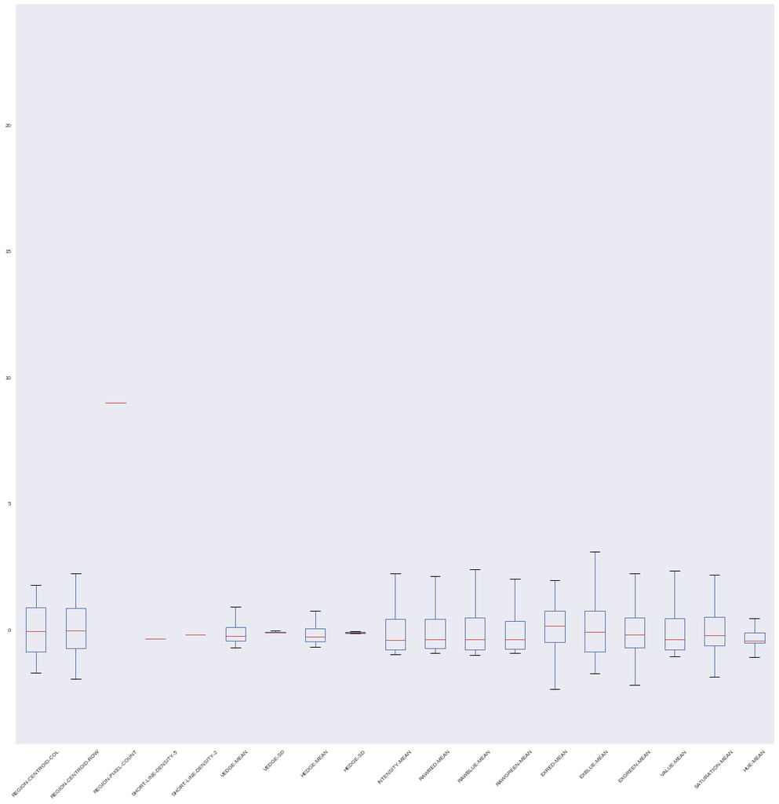

```python
boxplot = total_df_normalized_zscore2.boxplot(grid=False, fontsize=8, rot=45, figsize=(20,20))
```

**Comment** : After Z Score Normalization we could see that data is not skewed much. So all attribute now have nearly the same range and we can extract patters/insights from the data easily. Moreover, we can see the correlation between the attributes.

## Dimensionality reduction

### 1) Feature Projection Using PCA

Getting PCA Components after Z Score Normalization on the dataset

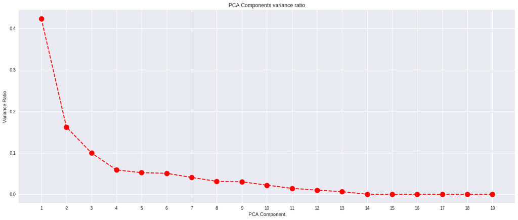

```python
from sklearn.decomposition import PCA
pca = PCA(n_components=19, random_state = 40)
pca.fit(total_df_normalized_zscore2)
plt.figure(figsize=(20,8))
plt.title('PCA Components variance ratio')
plt.xlabel('PCA Component')
plt.ylabel('Variance Ratio')
plt.xticks([i for i in range(1, 20)])
plt.plot([i for i in range(1, 20)], pca.explained_variance_ratio_, color='red', marker='o', linestyle='dashed', linewidth=2, markersize=12)
plt.show()
```

**Lets explore each the realation between number of PCA components taken and the covered variance ratio by simple plots.**

```
Total Covered Variance Ration with increasing number of PCA components =
 [0.42341135 0.58544784 0.68504234 0.74361518 0.79559514 0.84609887
 0.88651302 0.91771445 0.94771247 0.96966275 0.98388365 0.99381892
 0.99998259 1.         1.         1.         1.         1.
 1.        ]
```

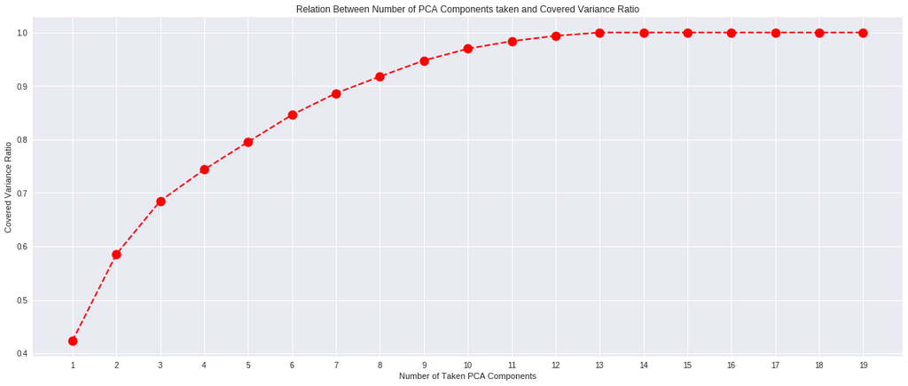

```python
print("Total Covered Variance Ration with increasing number of PCA components = \n {}".format(pca.explained_variance_ratio_.cumsum()))
plt.figure(figsize=(20,8))
plt.title('Relation Between Number of PCA Components taken and Covered Variance Ratio')
plt.xlabel('Number of Taken PCA Components')
plt.ylabel('Covered Variance Ratio')
plt.xticks([i for i in range(1, 20)])
plt.plot([i for i in range(1, 20)], pca.explained_variance_ratio_.cumsum(), color='red', marker='o', linestyle='dashed', linewidth=2, markersize=12)
plt.show()
```

**We will reduce the dimensions to 9 features covering 94.77% of total variance.**

```python
pca = PCA(9, random_state = 40)
pca.fit(total_df_normalized_zscore2)
total_df_final = pd.DataFrame(pca.transform(total_df_normalized_zscore2))
print("Dataset after applying PCA Dimensionality Reduction")
display(total_df_final)
```

```
Dataset after applying PCA Dimensionality Reduction
```

|  | 0 | 1 | 2 | 3 | 4 | 5 | 6 | 7 | 8 |
| --- | --- | --- | --- | --- | --- | --- | --- | --- | --- |
| 0 | -2.341008 | -0.568638 | -0.650548 | -0.477064 | -0.054783 | -0.136842 | 0.012842 | -0.620450 | 0.276409 |
| 1 | -2.397916 | -0.598568 | -0.432085 | -0.911518 | 0.367182 | -0.322516 | 0.011735 | -0.641841 | 0.313521 |
| 2 | -2.456240 | -0.543694 | -0.532037 | -0.138027 | -0.329315 | 0.081578 | -0.164498 | -0.599736 | 0.271298 |
| 3 | -2.605458 | -0.473095 | -0.649493 | 0.523324 | -0.986728 | 0.381044 | -0.184762 | -0.539207 | 0.292317 |
| 4 | -2.312929 | -0.446292 | -0.973609 | 0.452582 | -0.968599 | 0.242354 | -0.022998 | -0.538380 | 0.391014 |
| 5 | -2.492446 | -0.517895 | -0.825480 | 0.673388 | -1.143871 | 0.416263 | -0.137053 | -0.507198 | 0.357982 |
| 6 | -0.850164 | -0.286840 | -1.022699 | 2.614527 | 0.284934 | -1.136283 | 0.082629 | -0.881976 | 0.395378 |
| 7 | -1.329456 | -0.017900 | -0.791821 | 0.775720 | -1.054178 | 0.385493 | -0.718778 | -0.809541 | 0.777862 |
| 8 | -1.389388 | -0.302241 | -0.907463 | 0.792834 | -1.079289 | 0.389286 | -0.604281 | -0.824284 | 0.845216 |
| 9 | -0.894579 | -0.311445 | -0.964252 | 0.106209 | -0.404760 | 0.048909 | -0.463270 | -0.659446 | 0.661404 |
| 10 | -2.831070 | -0.558128 | -0.535644 | 0.650623 | -1.166638 | 0.478146 | -0.078941 | -0.387434 | 0.224812 |
| 11 | -0.356192 | -0.065483 | -1.526879 | 0.661129 | -1.022710 | 0.130760 | -0.257876 | -0.462538 | 0.774577 |
| 12 | -2.400785 | -0.490256 | -0.414389 | -0.987869 | 0.413980 | -0.384272 | 0.041169 | -0.570070 | 0.376185 |
| 13 | -0.868283 | -0.233381 | -0.889709 | 0.165235 | -0.390971 | 0.140612 | -0.610271 | -0.498080 | 0.541433 |
| 14 | -0.704694 | 0.007709 | -1.621150 | 0.836828 | -1.269256 | 0.180016 | -0.150910 | -0.597992 | 0.746484 |
| 15 | -2.447352 | -0.469687 | -0.480759 | -0.275101 | -0.217951 | -0.002813 | -0.142729 | -0.584755 | 0.328805 |
| 16 | -2.395432 | -0.573381 | -0.653218 | -0.534837 | -0.021191 | -0.184514 | 0.067807 | -0.561231 | 0.338590 |
| 17 | -1.223706 | -0.235239 | -1.079816 | 0.670161 | -1.029141 | 0.248634 | -0.432102 | -0.890383 | 0.855953 |
| 18 | -2.267972 | -0.539414 | -0.784887 | -0.464220 | -0.089441 | -0.181949 | 0.081068 | -0.555558 | 0.362339 |
| 19 | -2.355243 | -0.451762 | -0.421139 | -1.298803 | 0.695116 | -0.544987 | 0.117055 | -0.566964 | 0.314313 |
| 20 | -2.415680 | -0.580730 | -0.976334 | 0.602222 | -1.121863 | 0.332070 | 0.009125 | -0.527355 | 0.381817 |
| 21 | -0.068506 | 0.071893 | -1.275634 | -0.214001 | -0.122107 | -0.237934 | -0.312053 | -0.526885 | 0.548046 |
| 22 | -2.167593 | -0.428599 | -0.996515 | 0.500851 | -0.853078 | 0.439903 | -0.249983 | -0.038398 | -0.083173 |
| 23 | -0.886784 | -0.387908 | -0.969632 | 0.141301 | -0.480332 | 0.045291 | -0.390777 | -0.720113 | 0.745749 |
| 24 | -0.618009 | -0.244922 | -1.068004 | 0.008517 | -0.337640 | -0.060019 | -0.390835 | -0.734550 | 0.703893 |
| 25 | -0.627166 | -0.219141 | -0.901521 | -0.430246 | 0.169143 | -0.150004 | -0.478332 | -0.705897 | 0.267267 |
| 26 | -2.548358 | -0.429285 | -0.663902 | 0.669595 | -1.106627 | 0.442823 | -0.265343 | -0.451184 | 0.422497 |
| 27 | -2.372593 | -0.431942 | -0.606062 | -0.441074 | -0.044055 | -0.096734 | -0.102598 | -0.528722 | 0.239114 |
| 28 | -0.976053 | -0.017453 | -0.722548 | -0.203704 | -0.055769 | -0.030293 | -0.628267 | -0.644081 | 0.453291 |
| 29 | -0.151927 | -0.104299 | -1.380676 | 0.012769 | -0.369680 | -0.155158 | -0.244540 | -0.607657 | 0.646376 |
| ... | ... | ... | ... | ... | ... | ... | ... | ... | ... |
| 2280 | -0.417233 | 0.630532 | 0.009087 | 0.563467 | -0.484432 | 0.689053 | -1.562930 | -0.217581 | -0.252644 |
| 2281 | -0.076499 | 0.032193 | 0.054238 | -0.343297 | 0.322965 | 0.206305 | -1.180720 | 0.069117 | 0.210032 |
| 2282 | -2.260460 | 1.720556 | -1.051720 | -0.943835 | 2.968902 | 2.466342 | 2.230031 | 0.639090 | 0.574586 |
| 2283 | -2.461123 | -0.298521 | -0.389486 | -0.596323 | 0.158843 | -0.046708 | -0.340213 | -0.678892 | -0.014749 |
| 2284 | -2.564708 | -0.319531 | -0.549513 | -0.590062 | 0.104030 | -0.050977 | -0.146667 | -0.498902 | -0.219202 |
| 2285 | -2.539006 | -0.170210 | -0.559771 | -0.303777 | -0.129504 | 0.089019 | -0.287163 | -0.469640 | -0.218128 |
| 2286 | -2.564708 | -0.319531 | -0.549513 | -0.590062 | 0.104030 | -0.050977 | -0.146667 | -0.498902 | -0.219202 |
| 2287 | -2.679934 | -0.568697 | -0.495775 | -1.186571 | 0.604213 | -0.356018 | 0.106460 | -0.365279 | -0.081148 |
| 2288 | -2.370120 | -0.491215 | -0.687973 | -0.811786 | 0.317437 | -0.170629 | 0.027574 | -0.172158 | -0.247726 |
| 2289 | -1.451981 | 5.027101 | -0.344023 | 0.649525 | -1.449621 | -0.186821 | -1.148095 | -0.687455 | -1.693504 |
| 2290 | -1.674475 | 4.206716 | -0.975779 | -0.498790 | 2.782234 | 2.299517 | 1.206155 | 3.688003 | 3.078727 |
| 2291 | -1.921055 | 1.383118 | -0.505433 | 1.343328 | 4.166974 | 1.386444 | 2.138109 | 0.348693 | 0.779627 |
| 2292 | -1.418236 | 4.108249 | -0.873107 | 0.082725 | 1.924712 | 2.768784 | 1.484813 | -0.277001 | -0.792147 |
| 2293 | -1.497908 | 1.861413 | -0.218857 | 0.280182 | -0.585677 | 0.157665 | -1.286483 | -0.659350 | -0.209640 |
| 2294 | -2.987303 | 0.001541 | 0.333486 | 2.410132 | 0.274852 | -1.044380 | 0.085629 | -0.156163 | 0.644929 |
| 2295 | -1.620940 | 1.427714 | -0.365429 | 0.081564 | -0.416651 | 0.080264 | -0.998128 | -0.226053 | -0.028899 |
| 2296 | -2.942961 | -0.572694 | -0.979898 | -1.568447 | 0.805838 | -0.580868 | 0.799066 | 0.323265 | -0.765742 |
| 2297 | -1.705186 | 4.036820 | -0.960581 | -0.666695 | 2.268411 | 1.803446 | 2.157470 | 2.510725 | 2.490389 |
| 2298 | -2.643369 | -0.099693 | -0.946409 | 0.395869 | -0.850548 | 0.341123 | -0.143661 | 0.211036 | 0.007174 |
| 2299 | -2.491862 | -0.586820 | -0.345339 | 0.745650 | -1.064484 | 0.588740 | -0.765258 | -0.939826 | 0.802365 |
| 2300 | -1.788323 | 1.973615 | -0.245073 | -0.524448 | 0.028144 | -0.119278 | -0.801171 | -1.614167 | -1.963808 |
| 2301 | -2.427071 | -0.403586 | -0.284193 | 0.076459 | -0.439914 | 0.233545 | -0.630989 | -0.599898 | 0.765373 |
| 2302 | -3.013091 | -0.544399 | -1.313759 | -0.808496 | 0.084595 | -0.210945 | 0.839543 | 0.543423 | -1.037923 |
| 2303 | -1.932325 | -0.223858 | -0.075978 | 1.215037 | 1.685135 | -1.501472 | -0.032612 | -0.018654 | 0.051535 |
| 2304 | -1.992982 | -0.032266 | -0.453104 | -1.321766 | 0.925510 | -0.434403 | -0.273926 | 0.225530 | 0.058388 |
| 2305 | -1.937361 | -0.339952 | -0.854709 | 0.535326 | -0.796780 | 0.489509 | -0.484957 | 0.015889 | 0.015209 |
| 2306 | -1.968557 | -0.368023 | -0.434357 | 2.729732 | 0.266879 | -0.755541 | -0.174505 | 0.139946 | 0.095165 |
| 2307 | -1.998945 | -0.433207 | -0.685500 | -0.361757 | 0.031374 | 0.084551 | -0.306185 | -0.040331 | -0.149960 |
| 2308 | -1.871965 | -0.071748 | -0.557682 | -0.540197 | 0.227348 | -0.053320 | -0.464357 | 0.113399 | 0.144165 |
| 2309 | -1.729723 | -0.209252 | -0.209138 | 1.688314 | 1.328079 | -1.206102 | -0.198624 | -0.017272 | -0.233585 |

2310 rows × 9 columns

Visualize the correlation matrix of your dataset after applying PCA

|  | 0 | 1 | 2 | 3 | 4 | 5 | 6 | 7 | 8 |
| --- | --- | --- | --- | --- | --- | --- | --- | --- | --- |
| 0 | 1.000000e+00 | -9.573551e-17 | 7.991010e-16 | -2.056296e-16 | 1.062607e-16 | 1.719290e-16 | -7.281850e-17 | -5.953364e-16 | 4.415442e-16 |
| 1 | -9.573551e-17 | 1.000000e+00 | 5.236509e-16 | 2.506700e-16 | -1.589979e-16 | 2.183594e-16 | 3.537513e-17 | -6.169096e-16 | -3.436958e-16 |
| 2 | 7.991010e-16 | 5.236509e-16 | 1.000000e+00 | 1.352916e-16 | 2.298774e-16 | 8.935844e-17 | -1.414233e-16 | 1.243056e-17 | -3.032894e-16 |
| 3 | -2.056296e-16 | 2.506700e-16 | 1.352916e-16 | 1.000000e+00 | -1.511718e-16 | 3.416844e-17 | -3.829773e-16 | 1.164106e-16 | -1.582278e-16 |
| 4 | 1.062607e-16 | -1.589979e-16 | 2.298774e-16 | -1.511718e-16 | 1.000000e+00 | 6.947705e-16 | -2.911637e-16 | -2.805364e-18 | 7.174255e-17 |
| 5 | 1.719290e-16 | 2.183594e-16 | 8.935844e-17 | 3.416844e-17 | 6.947705e-16 | 1.000000e+00 | 7.249666e-16 | -1.874959e-16 | -5.230673e-17 |
| 6 | -7.281850e-17 | 3.537513e-17 | -1.414233e-16 | -3.829773e-16 | -2.911637e-16 | 7.249666e-16 | 1.000000e+00 | -1.889111e-17 | 5.871706e-17 |
| 7 | -5.953364e-16 | -6.169096e-16 | 1.243056e-17 | 1.164106e-16 | -2.805364e-18 | -1.874959e-16 | -1.889111e-17 | 1.000000e+00 | 4.698216e-16 |
| 8 | 4.415442e-16 | -3.436958e-16 | -3.032894e-16 | -1.582278e-16 | 7.174255e-17 | -5.230673e-17 | 5.871706e-17 | 4.698216e-16 | 1.000000e+00 |

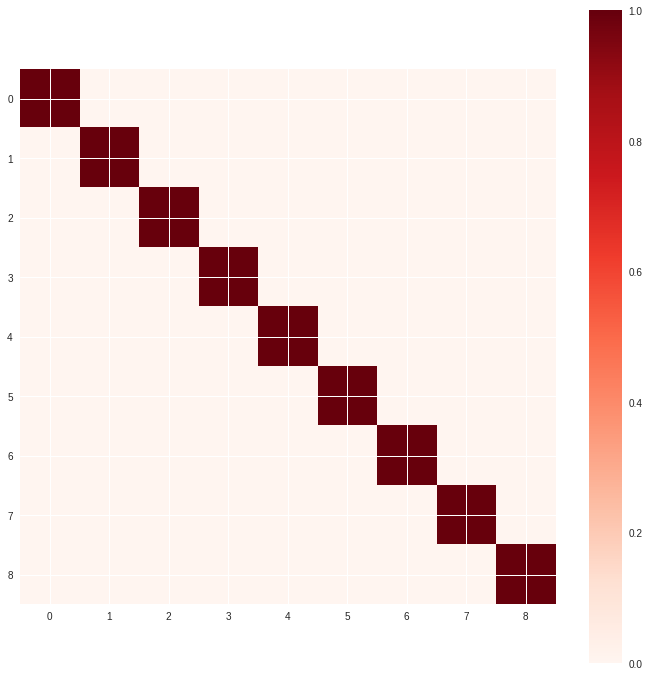

```python
display(total_df_final.corr())
visualize_coeff_matrix(total_df_final.corr())
```

**Conclusion:** From the previous heatmap we can see that all attributes are not correlated. And we actually expect that as PCA gives the resulting vectors (each being a linear combination of the variables and containing n observations) are an **uncorrelated orthogonal basis set.**

### Making PCA from scratch

```python
def eign_values (matrix) :
  [ values , vectors ] = np.linalg.eig(matrix)
  return { "values" : values , "vectors" : vectors }
```

```python
eign = eign_values(total_df_normalized_zscore2.cov())
display(eign["values"])
```

```
array([7.62470498e+00, 2.91791997e+00, 1.79347755e+00, 1.05476759e+00,
       9.36044614e-01, 9.09460719e-01, 7.27769748e-01, 5.61868991e-01,
       5.40198242e-01, 3.95276235e-01, 2.56087079e-01, 1.10994011e-01,
       1.78912307e-01, 3.13545971e-04, 1.42478751e-15, 1.93937067e-15,
       2.70301019e-15, 2.40876854e-15, 0.00000000e+00])
```

```python
def choose_dim_red (eign_values , threshold = 0.8) :
  sum_up = np.sum(eign_values)
  current = 0
  taken = 0
  for i in range (0, len(eign_values)) :
      current += eign_values[i]
      taken += 1
      if(current / sum_up >= threshold):
        return taken
  return len(eign_values)
```

```python
print('reduced number of attributes = {}'.format(choose_dim_red(eign["values"])))
```

```
reduced number of attributes = 6
```

```python
def reduce_pca (reduced_dim , eign_vectors , X) :
  eign_vectors = eign_vectors[:,0:reduced_dim]
  X = np.dot(X,eign_vectors)
  return X
```

```python
reduced_dim = choose_dim_red(eign["values"])
reduced_x = reduce_pca(reduced_dim , eign["vectors"] , X)
print("reduced X is of size : {}".format(np.shape(reduced_x)))
display(pd.DataFrame(reduced_x))
```

```
reduced X is of size : (2310, 6)
```

|  | 0 | 1 | 2 | 3 | 4 | 5 |
| --- | --- | --- | --- | --- | --- | --- |
| 0 | 7.817499 | 1.702180 | 65.171597 | 88.931843 | -110.929376 | 14.780890 |
| 1 | 8.180783 | 1.197225 | 75.245088 | 121.055043 | -142.329012 | 28.461007 |
| 2 | 12.308359 | 2.600203 | 65.759848 | 64.709922 | -91.159465 | 0.202632 |
| 3 | 14.852381 | 3.451594 | 55.254924 | 16.721722 | -45.870168 | -22.132145 |
| 4 | 7.193049 | 2.910645 | 45.655406 | 21.137942 | -44.842143 | -14.383170 |
| 5 | 13.080671 | 3.216212 | 48.883556 | 4.946844 | -33.265350 | -25.878483 |
| 6 | -35.068104 | 2.074546 | 31.271599 | 12.706425 | -27.771358 | -9.133130 |
| 7 | -17.381743 | 5.013035 | 46.537802 | 3.520356 | -26.428200 | -21.884053 |
| 8 | -16.902236 | 2.029885 | 44.462663 | 1.259293 | -25.147532 | -23.483860 |
| 9 | -30.942051 | 0.922854 | 53.143023 | 51.357088 | -70.520690 | 1.614825 |
| 10 | 21.194229 | 3.712360 | 56.206299 | 5.875490 | -37.074458 | -29.124692 |
| 11 | -47.439843 | 1.705689 | 27.426789 | 11.092374 | -23.489469 | -7.323475 |
| 12 | 7.893356 | 1.489104 | 75.100530 | 126.691727 | -146.526444 | 32.101217 |
| 13 | -29.430491 | 1.550018 | 58.276800 | 47.371445 | -70.068003 | -3.714899 |
| 14 | -38.355307 | 2.426786 | 18.834512 | -2.375942 | -8.878303 | -11.241310 |
| 15 | 11.262834 | 2.644217 | 67.110578 | 74.991681 | -99.859525 | 5.857318 |
| 16 | 8.125328 | 1.532994 | 65.511126 | 93.027556 | -114.523114 | 17.063640 |
| 17 | -23.395317 | 1.639695 | 37.538600 | 10.249931 | -28.727506 | -14.144544 |
| 18 | 4.984907 | 1.496543 | 61.311424 | 87.881067 | -108.189763 | 16.305967 |
| 19 | 6.523977 | 1.188312 | 77.627470 | 149.246309 | -166.652346 | 43.844888 |
| 20 | 9.882316 | 2.570719 | 45.000831 | 9.475989 | -35.048518 | -21.092465 |
| 21 | -56.291592 | 1.222014 | 44.466248 | 76.871355 | -85.744850 | 22.585028 |
| 22 | 12.117458 | 3.993356 | 58.906144 | 15.793770 | -48.394312 | -26.002712 |
| 23 | -31.730218 | 0.082549 | 50.602448 | 48.237660 | -66.162410 | 1.299672 |
| 24 | -40.540660 | 0.675240 | 49.259037 | 59.260814 | -74.052220 | 9.114680 |
| 25 | -38.008148 | 0.357208 | 62.394282 | 91.671270 | -108.805911 | 20.064635 |
| 26 | 15.250196 | 3.866994 | 53.300095 | 5.921001 | -36.012262 | -27.455754 |
| 27 | 9.020126 | 2.430482 | 67.920232 | 87.203067 | -111.056368 | 12.289821 |
| 28 | -27.052246 | 2.288199 | 63.016974 | 75.353652 | -95.226929 | 10.410083 |
| 29 | -54.682704 | 0.833169 | 39.185675 | 59.468334 | -68.837098 | 15.222989 |
| ... | ... | ... | ... | ... | ... | ... |
| 2280 | -31.263407 | 12.994739 | 89.178349 | 22.558147 | -57.337269 | -30.588679 |
| 2281 | -44.711287 | 2.252803 | 100.963192 | 86.344512 | -117.139287 | -0.926765 |
| 2282 | 9.375137 | 14.506107 | 91.656089 | 163.131963 | -182.152475 | 48.158901 |
| 2283 | 21.668600 | 5.851931 | 76.973170 | 96.770869 | -122.939855 | 12.759557 |
| 2284 | 21.977722 | 5.438391 | 76.653840 | 95.409792 | -121.736312 | 12.019430 |
| 2285 | 21.778683 | 7.249576 | 73.408303 | 75.655219 | -103.616841 | 2.445451 |
| 2286 | 21.977722 | 5.438391 | 76.653840 | 95.409792 | -121.736312 | 12.019430 |
| 2287 | 23.974027 | 2.521290 | 85.503269 | 136.727812 | -160.884223 | 31.019253 |
| 2288 | 15.001868 | 2.694474 | 79.745846 | 110.665014 | -136.882985 | 18.699699 |
| 2289 | -10.149751 | 135.931093 | 77.664500 | 20.242380 | -4.949746 | 18.293479 |
| 2290 | -1.249794 | 16.615913 | 87.990011 | 138.915045 | -162.048872 | 35.122622 |
| 2291 | 4.417252 | 5.553637 | 87.506648 | 142.736645 | -167.633835 | 34.161133 |
| 2292 | -9.355389 | 85.655793 | 87.442380 | 96.681988 | -97.275637 | 34.886421 |
| 2293 | 2.971825 | 53.893660 | 72.527068 | 41.100361 | -56.544505 | -1.105025 |
| 2294 | 20.735120 | 8.949952 | 66.925729 | 24.763953 | -53.134530 | -19.516398 |
| 2295 | 2.720254 | 41.700430 | 74.466123 | 53.573072 | -72.333701 | 0.800637 |
| 2296 | 22.319983 | 2.070083 | 90.054443 | 161.799127 | -184.094172 | 43.218268 |
| 2297 | -3.085050 | 67.938040 | 90.996198 | 142.305873 | -137.922494 | 64.808722 |
| 2298 | 23.338637 | 6.453050 | 61.040230 | 22.949751 | -54.686541 | -22.341126 |
| 2299 | 29.754014 | 4.448767 | 56.944791 | -1.971940 | -31.586169 | -35.112554 |
| 2300 | 3.493277 | 72.689123 | 87.329334 | 99.798063 | -105.796379 | 29.288062 |
| 2301 | 25.469837 | 4.908709 | 66.986646 | 47.385102 | -77.619218 | -11.172122 |
| 2302 | 22.900409 | 3.001935 | 78.486420 | 106.143879 | -132.918766 | 16.365975 |
| 2303 | 5.082531 | 4.883710 | 83.800046 | 110.128414 | -136.957096 | 17.929751 |
| 2304 | 6.755751 | 4.028423 | 91.638981 | 150.704398 | -175.721031 | 36.411478 |
| 2305 | 7.946996 | 4.584194 | 63.088170 | 14.593891 | -48.989632 | -28.545114 |
| 2306 | 9.155756 | 5.229401 | 62.112414 | -1.730520 | -34.010765 | -36.870314 |
| 2307 | 8.192747 | 3.107963 | 77.406717 | 79.483049 | -110.229279 | 1.565869 |
| 2308 | 4.687083 | 4.377382 | 80.132567 | 94.430110 | -123.041442 | 9.797749 |
| 2309 | 1.605751 | 4.432228 | 78.652578 | 76.451901 | -107.399695 | 0.022481 |

2310 rows × 6 columns